# Capstone - CKME136

Ade Adeoye

28/05/2020

- Introduction
- Data Preprocessing & cleaning
- Exploratory Data Analysis
- Missing Values
  - Imputing using KNN
  - Multiple Correspondence Analysis
- Class Balancing
- Model Fitting
  - Decision Tree
  - Naive-Bayes
  - Logistic Regression
  - Artificial Neural Networks
- Feature Engineering
- Results
- Conclusion and Recommendations
- References

## Introduction

Breast cancer is one of the leading causes of cancer-related deaths in the world. Its incidence is however quite biased. According to the Centers for Disease Control and Prevention (CDC), most cases of breast cancer are found in women, with estimates putting the likelihood at about a hundred times more likely than in males. For cancer-related diseases, early detection is crucial. If discovered early, a patient is highly likely to survive the disease, even if there may be a few cases of recurrence. This has given rise to a suite of data mining and machine learning efforts attempting to gain an advantage against this ailment by predicting the chances of a patient developing the disease, or if diagnosed already, the chances of the cancer remaining benign or turning malignant.

In this study, we examine a breast cancer data set obtained from the University Medical Centre, Institute of Oncology, Ljubljana, Yugoslavia; and, applying a range of machine learning techniques, we predict the chances of recurrence of breast cancer in 286 patients. The essential part of the data mining procedure conducted is classification, where we categorize the sample according to its original binary split using a range of classification methods. The methods used include decision tree, naïve-Bayes, logistic regression, and neural networks. As a conclusive analysis, we conduct a comparison of the metrics of these classification models, examining how the different models performed on the sample data..

## Data Preprocessing & cleaning

Unlike most data sets, this data set has all categorical attributes. This presents unique challenges, as it means we are unable to immediately use many of the widely numerical approaches in deriving insights. However, this does not detract from our overall objective of determining how the different attributes serve as indicators of possible recurrence of breast cancer in a patient.

First, we read in the data set into R’s workspace using `read_csv` from the `readr` package. This ensures that we read in the data as a tibble and not automatically convert the attributes into factors. The data has no header. As a result, header is set to FALSE (`header = FALSE`) and will be set manually. There is a handful of missing data in the data set originally represented as “?”. These have been converted to NA.

```r
#Load readr package
library(readr)

#Read in data using read_csv
bdata <- read_csv('./data/breast-cancer.data', col_names = FALSE, na = c("?", NA))
#Check first 6 rows of data
head(bdata)
```

```
## # A tibble: 6 x 10
##   X1                  X2    X3      X4    X5    X6       X7 X8    X9       X10
##   <chr>               <chr> <chr>   <chr> <chr> <chr> <dbl> <chr> <chr>    <chr>
## 1 no-recurrence-even~ 30-39 premeno 30-34 0-2   no        3 left  left_low no
## 2 no-recurrence-even~ 40-49 premeno 20-24 0-2   no        2 right right_up no
## 3 no-recurrence-even~ 40-49 premeno 20-24 0-2   no        2 left  left_low no
## 4 no-recurrence-even~ 60-69 ge40    15-19 0-2   no        2 right left_up  no
## 5 no-recurrence-even~ 40-49 premeno 0-4   0-2   no        2 right right_l~ no
## 6 no-recurrence-even~ 60-69 ge40    15-19 0-2   no        2 left  left_low no
```

The attribute names are obtained from the accompanying `names` file found in the same folder as the data on the UCI machine learning database. We have the following attributes for this data: `class`, `age`, `menopause`, `tumorSize`, `invNodes`, `nodeCaps`, `degMalig`, `breast`, `breastQuad` and `irradiat`. The description for each are given in the word document accompanying this analysis. However, for completeness, we will elaborate a little about each of these attributes in the `rmd` document.

```r
#Rename columns in data set
cnames <- c("class", "age", "menopause", "tumorSize", "invNodes", "nodeCaps", "degMalig", "breast", "breastQuad", "irradiat")

#Pass columns into dataframe
colnames(bdata) <- cnames

#Display head
head(bdata)
```

```
## # A tibble: 6 x 10
##   class age   menopause tumorSize invNodes nodeCaps degMalig breast breastQuad
##   <chr> <chr> <chr>     <chr>     <chr>    <chr>       <dbl> <chr>  <chr>
## 1 no-r~ 30-39 premeno   30-34     0-2      no              3 left   left_low
## 2 no-r~ 40-49 premeno   20-24     0-2      no              2 right  right_up
## 3 no-r~ 40-49 premeno   20-24     0-2      no              2 left   left_low
## 4 no-r~ 60-69 ge40      15-19     0-2      no              2 right  left_up
## 5 no-r~ 40-49 premeno   0-4       0-2      no              2 right  right_low
## 6 no-r~ 60-69 ge40      15-19     0-2      no              2 left   left_low
## # ... with 1 more variable: irradiat <chr>
```

We examine the structure of the data set.

```r
str(bdata)
```

```
## Classes 'spec_tbl_df', 'tbl_df', 'tbl' and 'data.frame': 286 obs. of  10 variables:
##  $ class     : chr  "no-recurrence-events" "no-recurrence-events" "no-recurrence-events" "no-recurrence-events" ...
##  $ age       : chr  "30-39" "40-49" "40-49" "60-69" ...
##  $ menopause : chr  "premeno" "premeno" "premeno" "ge40" ...
##  $ tumorSize : chr  "30-34" "20-24" "20-24" "15-19" ...
##  $ invNodes  : chr  "0-2" "0-2" "0-2" "0-2" ...
##  $ nodeCaps  : chr  "no" "no" "no" "no" ...
##  $ degMalig  : num  3 2 2 2 2 2 2 1 2 2 ...
##  $ breast    : chr  "left" "right" "left" "right" ...
##  $ breastQuad: chr  "left_low" "right_up" "left_low" "left_up" ...
##  $ irradiat  : chr  "no" "no" "no" "no" ...
##  - attr(*, "spec")=
##   .. cols(
##   ..   X1 = col_character(),
##   ..   X2 = col_character(),
##   ..   X3 = col_character(),
##   ..   X4 = col_character(),
##   ..   X5 = col_character(),
##   ..   X6 = col_character(),
##   ..   X7 = col_double(),
##   ..   X8 = col_character(),
##   ..   X9 = col_character(),
##   ..   X10 = col_character()
##   .. )
```

`class` is the target binary variable identifying whether a patient experienced breast cancer recurrence or not. It has been read into the workspace as a character attribute, but we will change it into a factor variable with two levels: `recurrence-events` and `non-recurrence-events`.

`age` identifies the patients’ ages at the time of diagnosis. This is specified in bins of 9, which seem quite sufficient enough for our analysis. At the moment, it has been read into R as a character, though it is better converted into a factor variable with 6 levels.

`menopause` indicates whether the patient is pre-, or post-menopausal at the time of diagnosis. It is a tenary variable with three unique values, and is expressed as a function of age when menopause sets in. `premeno` identifies patients who are pre-menopausal, while `ge40` and `lt40` identifies post-menopausal patients who are greater than and less than 40 years old, respectively.

`tumorSize` describes the greatest diameter in mm of the removed or excised tumor. It exists in bins of 4 and works better in our subsequently analysis as a factor variable.

`invNodes` is the number of auxillary lymph nodes with visible metastic breast cancer at the time of diagnosis. It ranges from 0 to 26 in bins of 2. This also works better as a factor variable. The higher the number of infected lymph nodes, the more the cancer has metastized away from it source.

```r
#Unique values of tumor size
unique(bdata$tumorSize)
```

```
##  [1] "30-34" "20-24" "15-19" "0-4"   "25-29" "50-54" "10-14" "40-44" "35-39"
## [10] "5-9"   "45-49"
```

```r
#Unique values of invNodes
unique(bdata$invNodes)
```

```
## [1] "0-2"   "6-8"   "9-11"  "3-5"   "15-17" "12-14" "24-26"
```

`nodeCaps` is a binary variable indicating whether the cancer metastasized into a lymph node or not. Our body’s immune system contains a network of lymph vessels and lymph nodes which collects fluid, waste, viruses and bacteria that are in the body tissues, outside the bloodstream. When cancer cells develop in the body, they may break away and end up in the lymph nodes near the developed tumor in a process called metastasis. According to oncologists, this often increases the chance that the cancer might return. In our analysis, we may expect that this variable could contribute rather significantly to the chances of a relapse in the patients.

The `degMalig` attribute identifies the histological grade (range 1-3) of the tumor. Tumors that are grade 1 predominantly consist of cells that, while neoplastic, retain many of their usual characteristics. Grade 2 tumors look a lot less like normal cells and show increasing growth, while grade 3 tumors predominately consist of cells that are highly abnormal.

`breast` is another binary variable indicating on which of patient’s breast the tumor occured. This could happen on the left or right breast.

`breastQuad` is the location of the tumor within the breast area (upper left, upper right, central, lower left, or lower right)

`irradiat` indicates whether the patient received radiation therapy or not. Radiation therapy is a treatment that uses high-particle waves, such as x-rays, gamma rays or electron beams to destroy or damage cancer cells. It works by keeping cancer cells from growing and dividing, causing them to die.

We will now convert all of these variables to the appropriate factor formats in order to enable better analysis. The models are better suited at handling a factor format than a character format. Morever, the data types are either nominal or ordinal.

```r
library(dplyr)
library(tidyr)

#Get column names
cols <- names(bdata)

#Convert all columns to factor format
bdata[cols] <- lapply(bdata[cols], factor)

#Examine new structure of data set
str(bdata)
```

```
## Classes 'spec_tbl_df', 'tbl_df', 'tbl' and 'data.frame': 286 obs. of  10 variables:
##  $ class     : Factor w/ 2 levels "no-recurrence-events",..: 1 1 1 1 1 1 1 1 1 1 ...
##  $ age       : Factor w/ 6 levels "20-29","30-39",..: 2 3 3 5 3 5 4 5 3 3 ...
##  $ menopause : Factor w/ 3 levels "ge40","lt40",..: 3 3 3 1 3 1 3 1 3 3 ...
##  $ tumorSize : Factor w/ 11 levels "0-4","10-14",..: 6 4 4 3 1 3 5 4 11 4 ...
##  $ invNodes  : Factor w/ 7 levels "0-2","12-14",..: 1 1 1 1 1 1 1 1 1 1 ...
##  $ nodeCaps  : Factor w/ 2 levels "no","yes": 1 1 1 1 1 1 1 1 1 1 ...
##  $ degMalig  : Factor w/ 3 levels "1","2","3": 3 2 2 2 2 2 2 1 2 2 ...
##  $ breast    : Factor w/ 2 levels "left","right": 1 2 1 2 2 1 1 1 1 2 ...
##  $ breastQuad: Factor w/ 5 levels "central","left_low",..: 2 5 2 3 4 2 2 2 2 3 ...
##  $ irradiat  : Factor w/ 2 levels "no","yes": 1 1 1 1 1 1 1 1 1 1 ...
##  - attr(*, "spec")=
##   .. cols(
##   ..   X1 = col_character(),
##   ..   X2 = col_character(),
##   ..   X3 = col_character(),
##   ..   X4 = col_character(),
##   ..   X5 = col_character(),
##   ..   X6 = col_character(),
##   ..   X7 = col_double(),
##   ..   X8 = col_character(),
##   ..   X9 = col_character(),
##   ..   X10 = col_character()
##   .. )
```

```r
#Examine first few records
head(bdata)
```

```
## # A tibble: 6 x 10
##   class age   menopause tumorSize invNodes nodeCaps degMalig breast breastQuad
##   <fct> <fct> <fct>     <fct>     <fct>    <fct>    <fct>    <fct>  <fct>
## 1 no-r~ 30-39 premeno   30-34     0-2      no       3        left   left_low
## 2 no-r~ 40-49 premeno   20-24     0-2      no       2        right  right_up
## 3 no-r~ 40-49 premeno   20-24     0-2      no       2        left   left_low
## 4 no-r~ 60-69 ge40      15-19     0-2      no       2        right  left_up
## 5 no-r~ 40-49 premeno   0-4       0-2      no       2        right  right_low
## 6 no-r~ 60-69 ge40      15-19     0-2      no       2        left   left_low
## # ... with 1 more variable: irradiat <fct>
```

There is not much descriptive statistics we can conduct on this data set composed entirely of categorical variables besides obtaining the mode for each attribute and generating the summary statistics.

To obtain the mode, we can use the `sapply` function.

```r
sapply(bdata, function(x) which.max(summary(x))) %>% names
```

```
##  [1] "class.no-recurrence-events" "age.50-59"
##  [3] "menopause.premeno"          "tumorSize.30-34"
##  [5] "invNodes.0-2"               "nodeCaps.no"
##  [7] "degMalig.2"                 "breast.left"
##  [9] "breastQuad.left_low"        "irradiat.no"
```

Preceeding the dot after each attribute is the modal value for each attribute.

Now, we examine a summary of the data set to observe missing or unusual values.

```r
summary(bdata)
```

```
##                   class        age       menopause     tumorSize   invNodes
##  no-recurrence-events:201   20-29: 1   ge40   :129   30-34  :60   0-2  :213
##  recurrence-events   : 85   30-39:36   lt40   :  7   25-29  :54   12-14:  3
##                             40-49:90   premeno:150   20-24  :50   15-17:  6
##                             50-59:96                 15-19  :30   24-26:  1
##                             60-69:57                 10-14  :28   3-5  : 36
##                             70-79: 6                 40-44  :22   6-8  : 17
##                                                      (Other):42   9-11 : 10
##  nodeCaps   degMalig   breast        breastQuad  irradiat
##  no  :222   1: 71    left :152   central  : 21   no :218
##  yes : 56   2:130    right:134   left_low :110   yes: 68
##  NA's:  8   3: 85                left_up  : 97
##                                  right_low: 24
##                                  right_up : 33
##                                  NA's     :  1
##
```

There is some missing data under `nodeCaps` and `breastQuad`. We take a closer look at the data set and identify which of the rows contain these missing values. We could subset the data set in order to see these rows.

```r
bdata %>% subset(is.na(nodeCaps)  | is.na(breastQuad))
```

```
## # A tibble: 9 x 10
##   class age   menopause tumorSize invNodes nodeCaps degMalig breast breastQuad
##   <fct> <fct> <fct>     <fct>     <fct>    <fct>    <fct>    <fct>  <fct>
## 1 no-r~ 40-49 premeno   25-29     0-2      <NA>     2        left   right_low
## 2 no-r~ 60-69 ge40      25-29     3-5      <NA>     1        right  left_up
## 3 no-r~ 60-69 ge40      25-29     3-5      <NA>     1        right  left_low
## 4 no-r~ 50-59 ge40      30-34     9-11     <NA>     3        left   left_up
## 5 no-r~ 50-59 ge40      30-34     9-11     <NA>     3        left   left_low
## 6 recu~ 50-59 ge40      30-34     0-2      no       3        left   <NA>
## 7 recu~ 70-79 ge40      15-19     9-11     <NA>     1        left   left_low
## 8 recu~ 50-59 lt40      20-24     0-2      <NA>     1        left   left_up
## 9 recu~ 50-59 lt40      20-24     0-2      <NA>     1        left   left_low
## # ... with 1 more variable: irradiat <fct>
```

The missing records are all under `nodeCaps` and `breastQuad`. There are 8 missing items under `nodeCaps` and 1 missing item under `breastQuad`. Later we attempt to imput these missing values. Imputting is done after exploratory data analysis so that we can gain a global view of the data set before imputting.

Additionally, the class distribution between recurrent and non-recurrent cases appear quite unbalanced. There are 201 no-recurrence-events and 85 recurrence-events. This means in the sampling conducted to obtain this data set, more women who were sampled did not have a relapse. Such imbalance could have a detrimental effect on our subsequent machine learning analysis; therefore, this means we need to take special precaution by adequately treating this imbalance. We examine strategies for balancing the data set under “Class Balancing”.

Using the `table` function, we examine the distribution of the different attributes relative to the class attribute.

```r
with(bdata, table(class, age))
```

```
##                       age
## class                  20-29 30-39 40-49 50-59 60-69 70-79
##   no-recurrence-events     1    21    63    71    40     5
##   recurrence-events        0    15    27    25    17     1
```

This not only confirms the class imbalance earlier observed in the `class` attributes, it also shows that this imbalance extends to other attributes when viewed in relation to the `class` attribute. In raw numbers, this is not immediately visible. When examined in proportions, it becomes clearer that there are much more “no-recurrence-events” than there are “recurrence-events”.

```r
#Examine class split along age in proportion
with(bdata, 100 * prop.table(table(class, age))) %>% round(2)
```

```
##                       age
## class                  20-29 30-39 40-49 50-59 60-69 70-79
##   no-recurrence-events  0.35  7.34 22.03 24.83 13.99  1.75
##   recurrence-events     0.00  5.24  9.44  8.74  5.94  0.35
```

This global proportion shows the size of each element against the whole group. The largest proportion is made up of people in the age group 50-59 who have no recurrent incidents. The lowest, on the other hand, is the element representing the age group 20-29 who have recurrent cases. Another observation is that all the elements are not equally distributed throughout the table. For patients between the ages of 40 to 49, there are more than 2 times the number with no recurrent cases than there are with recurrent cases. This is about the same for patients between the ages of 60 to 69, but even worse for patients between the ages of 50 to 59. For all other patients, age distribution relative to recurrence-events seems about even. However, we can’t say much for distribution per group. Examining the table proportions row-wise may help with this detail. This will show what the size of each class is per age group.

```r
#Examine class split along age in proportion, row-wise
with(bdata, 100 * prop.table(table(class, age), 2)) %>% round(2)
```

```
##                       age
## class                   20-29  30-39  40-49  50-59  60-69  70-79
##   no-recurrence-events 100.00  58.33  70.00  73.96  70.18  83.33
##   recurrence-events      0.00  41.67  30.00  26.04  29.82  16.67
```

```r
#Examine class split along nodeCaps
with(bdata, 100 * prop.table(table(class, nodeCaps))) %>% round(2)
```

```
##                       nodeCaps
## class                     no   yes
##   no-recurrence-events 61.51  8.99
##   recurrence-events    18.35 11.15
```

While there does not seem to be a lot of imbalance in the `class` attributes relative to those who experienced a metastatization into a lymph node, the split is heavily biased for those who did not. Again, this could be detrimental to model fitting and will need to be properly managed.

```r
#Examine class split along degMalig
with(bdata, 100 * prop.table(table(class, degMalig))) %>% round(2)
```

```
##                       degMalig
## class                      1     2     3
##   no-recurrence-events 20.63 35.66 13.99
##   recurrence-events     4.20  9.79 15.73
```

For patients with grade 1 and 2 tumors, the split between those with “recurrence-events” and those without is heavily biased towards those without. The ratio is as high as 5 for patients with grade 1 tumor. For patients with grade 3 tumor, the split is about even.

We create a temporary data set called `bdata_alt` which converts some of the binned data into float types so that we can make additional plots. For example, to plot a histogram we will need to have the data in numeric form.

First, we create a new feature consisting of data which is numeric and call this `bdata_alt`.

```r
#Load required library
library(stringr)

#Create copy of existing data set
bdata_alt <- bdata

#Split age, tumorSize and invNodes attributes
bdata_alt$mage <- bdata_alt$age %>%
                    str_split("-") %>%
                    lapply(as.numeric) %>% lapply(mean) %>%
                    unlist

bdata_alt$mtumorSize <- bdata_alt$tumorSize %>%
                    str_split("-") %>%
                    lapply(as.numeric) %>% lapply(mean) %>%
                    unlist

bdata_alt$minvNodes <- bdata_alt$invNodes %>%
                    str_split("-") %>%
                    lapply(as.numeric) %>% lapply(mean) %>%
                    unlist

bdata_alt <- bdata_alt %>% mutate(degMalig = as.numeric(as.character(degMalig)))

#Extract the numeric attributes and other factors
bdata_malt <- bdata_alt %>%
  dplyr::select(-age, -tumorSize, -invNodes)

#Show head
head(bdata_malt)
```

```
## # A tibble: 6 x 10
##   class menopause nodeCaps degMalig breast breastQuad irradiat  mage mtumorSize
##   <fct> <fct>     <fct>       <dbl> <fct>  <fct>      <fct>    <dbl>      <dbl>
## 1 no-r~ premeno   no              3 left   left_low   no        34.5         32
## 2 no-r~ premeno   no              2 right  right_up   no        44.5         22
## 3 no-r~ premeno   no              2 left   left_low   no        44.5         22
## 4 no-r~ ge40      no              2 right  left_up    no        64.5         17
## 5 no-r~ premeno   no              2 right  right_low  no        44.5          2
## 6 no-r~ ge40      no              2 left   left_low   no        64.5         17
## # ... with 1 more variable: minvNodes <dbl>
```

```r
str(bdata_malt)
```

```
## Classes 'spec_tbl_df', 'tbl_df', 'tbl' and 'data.frame': 286 obs. of  10 variables:
##  $ class     : Factor w/ 2 levels "no-recurrence-events",..: 1 1 1 1 1 1 1 1 1 1 ...
##  $ menopause : Factor w/ 3 levels "ge40","lt40",..: 3 3 3 1 3 1 3 1 3 3 ...
##  $ nodeCaps  : Factor w/ 2 levels "no","yes": 1 1 1 1 1 1 1 1 1 1 ...
##  $ degMalig  : num  3 2 2 2 2 2 2 1 2 2 ...
##  $ breast    : Factor w/ 2 levels "left","right": 1 2 1 2 2 1 1 1 1 2 ...
##  $ breastQuad: Factor w/ 5 levels "central","left_low",..: 2 5 2 3 4 2 2 2 2 3 ...
##  $ irradiat  : Factor w/ 2 levels "no","yes": 1 1 1 1 1 1 1 1 1 1 ...
##  $ mage      : num  34.5 44.5 44.5 64.5 44.5 64.5 54.5 64.5 44.5 44.5 ...
##  $ mtumorSize: num  32 22 22 17 2 17 27 22 52 22 ...
##  $ minvNodes : num  1 1 1 1 1 1 1 1 1 1 ...
```

Now, we have a new dataframe with some attributes which are numeric.These are `mage`, `mtumorSize` and `minvNodes`. These have been calculated as averaged values of the range data provided. The other attributes are all factors.

In the latter stages of model building we will be working with other forms of this data set where one-hot encoding has been applied. After doing this, we will examine additional insights that could be gained from using this data set.

## Exploratory Data Analysis

Before beginning with some exploratory data analysis, we convert some of the variable which carry more meaning at increased values into ordinal. At the moment, these variables exist as factors, but better analysis can be derived from the data if they appear as ordinal instead, since at increasing values they represent worse cases. These are `tumorSize` and `invNodes`. A larger `tumorSize` in mm indicates a worse situation of the cancer case. Greater number of infected lymph nodes also show a worse case of metastization in the breast cancer patient. By ordering these factors, we will be able to see clearer in the visualizations that follow how they are associated with the age of the patients or with whether there was a case of recurrence.

All of the current variable adjustment will be done on the second copy of the dataframe, `bdata_alt`.

```r
#Convert tumorSize into ordinal variable
bdata_alt$tumorSize <- factor(bdata_alt$tumorSize, ordered = TRUE, levels = c("0-4", "5-9","10-14","15-19","20-24","25-29","30-34","35-39","40-44","45-49","50-54"))

#Convert invNodes into ordinal variable
bdata_alt$invNodes <- factor(bdata_alt$invNodes, ordered = TRUE, levels = c("0-2", "3-5","6-8","9-11","12-14","15-17","24-26"))

bdata_alt$degMalig <- factor(bdata_alt$degMalig, ordered = TRUE, levels = c(1,2,3))

#Examine structure of new data
str(bdata_alt)
```

```
## Classes 'spec_tbl_df', 'tbl_df', 'tbl' and 'data.frame': 286 obs. of  13 variables:
##  $ class     : Factor w/ 2 levels "no-recurrence-events",..: 1 1 1 1 1 1 1 1 1 1 ...
##  $ age       : Factor w/ 6 levels "20-29","30-39",..: 2 3 3 5 3 5 4 5 3 3 ...
##  $ menopause : Factor w/ 3 levels "ge40","lt40",..: 3 3 3 1 3 1 3 1 3 3 ...
##  $ tumorSize : Ord.factor w/ 11 levels "0-4"<"5-9"<"10-14"<..: 7 5 5 4 1 4 6 5 11 5 ...
##  $ invNodes  : Ord.factor w/ 7 levels "0-2"<"3-5"<"6-8"<..: 1 1 1 1 1 1 1 1 1 1 ...
##  $ nodeCaps  : Factor w/ 2 levels "no","yes": 1 1 1 1 1 1 1 1 1 1 ...
##  $ degMalig  : Ord.factor w/ 3 levels "1"<"2"<"3": 3 2 2 2 2 2 2 1 2 2 ...
##  $ breast    : Factor w/ 2 levels "left","right": 1 2 1 2 2 1 1 1 1 2 ...
##  $ breastQuad: Factor w/ 5 levels "central","left_low",..: 2 5 2 3 4 2 2 2 2 3 ...
##  $ irradiat  : Factor w/ 2 levels "no","yes": 1 1 1 1 1 1 1 1 1 1 ...
##  $ mage      : num  34.5 44.5 44.5 64.5 44.5 64.5 54.5 64.5 44.5 44.5 ...
##  $ mtumorSize: num  32 22 22 17 2 17 27 22 52 22 ...
##  $ minvNodes : num  1 1 1 1 1 1 1 1 1 1 ...
```

Here, we are also able to establish that, while `invNodes` has 7 levels, it is “missing” two bins, 18-20 and 21-23, among cases in the data set. This could be because these bins simply do not exist, or may have been unintentionally left out while gathering the data. Research into the source of the data shows no indication of the latter, so we are forced to accept that these cases simply do not exist. We will also be making no allowance for them.

The attribute most representative of each patient is their age. Examining a bar plot of `age` against `class` confirms the imbalance in the class distribution.

```r
library(ggthemes)
```

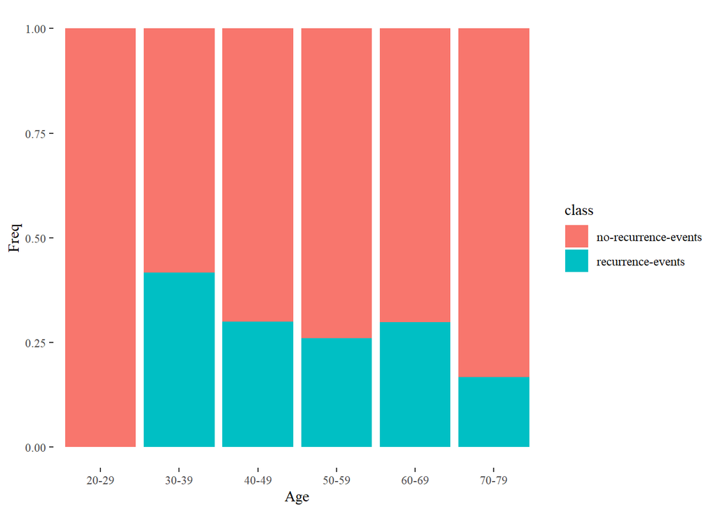

```r
library(ggplot2)
table(bdata$age, bdata$class) %>% as.data.frame %>% ggplot(aes(x = Var1, y = Freq, fill = Var2)) + geom_bar(stat = "identity", position = "fill") + labs(fill = "class") + xlab("Age") + theme_tufte()
```

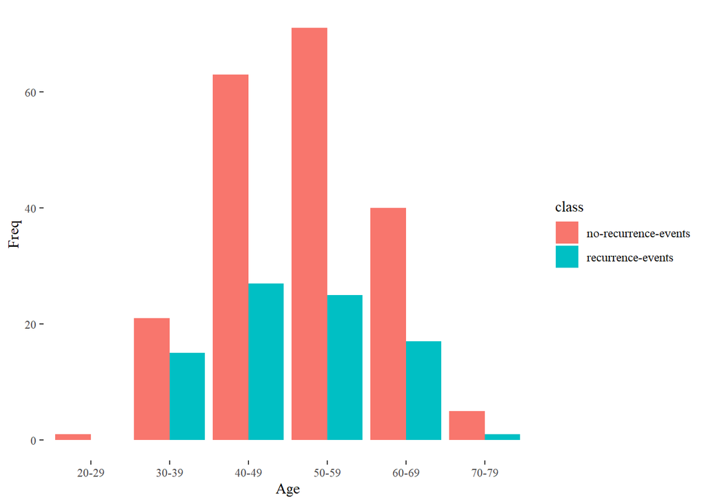

```r
table(bdata$age, bdata$class) %>% as.data.frame %>% ggplot(aes(x = Var1, y = Freq, fill = Var2)) + geom_bar(stat = "identity", position = "dodge") + labs(fill = "class") + xlab("Age") + theme_tufte()
```

We see, here, that recurrent events make up a smaller proportion of the cases in the available data. For ages between 20 and 29, there are no cases of recurrence. For those between 30 and 39, the recurrent cases are a little less than 50%. For other ages recurrent cases vary between 25 to 30%, with ages 70-79 registering the lowest value. Clearly, for all ages, non-recurrent cases dominate.

The `tumorSize` attribute shows even more detail in the data distribution among `class` and `age`. `tumorSize` refers to the greatest diameter of the excised tumor. As shown the produced plot, for most of the ages and cases (of non-recurrence and recurrence), the tumorSize lies between 10 and 39. Since the average tumor size in most breast cancer cases is about 1in (or 25mm), this sample data seems quite representative.

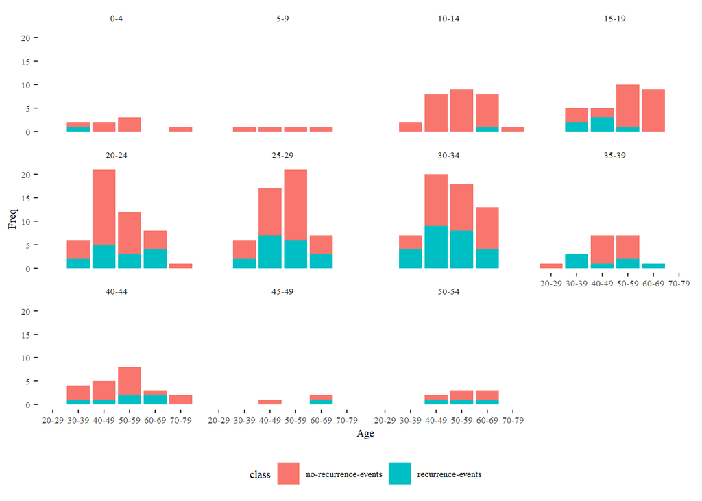

```r
bdata_alt1 <- bdata_alt

table(bdata_alt1$age, bdata_alt1$class, bdata_alt1$tumorSize, bdata_alt1$nodeCaps) %>% as.data.frame %>% ggplot(aes(x=Var1, y=Freq, fill=Var2)) + geom_bar(stat="identity") + facet_wrap(~Var3) + theme_tufte() + theme(legend.position = "bottom", text = element_text(size=8)) + labs(fill = "class") + xlab("Age")
```

Large tumor sizes often represent worse outcomes. Large tumor sizes suggest that more lymph nodes may be affected. This implies a correlation between `invNodes` and `tumorSize`. Though they may be correlated, they are however independent measures of outcome. Examining the relationship between these two attributes in our data could provide more information about this.

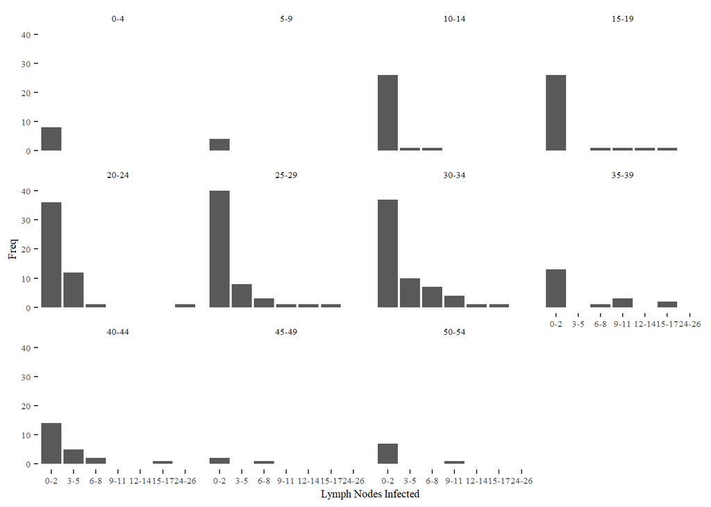

```r
table(bdata_alt$invNodes, bdata_alt$tumorSize) %>% as.data.frame %>% ggplot(aes(x=Var1, y = Freq)) + geom_bar(stat="identity") + facet_wrap(~Var2) + theme_tufte() + theme(text = element_text(size=8)) + xlab("Lymph Nodes Infected")
```

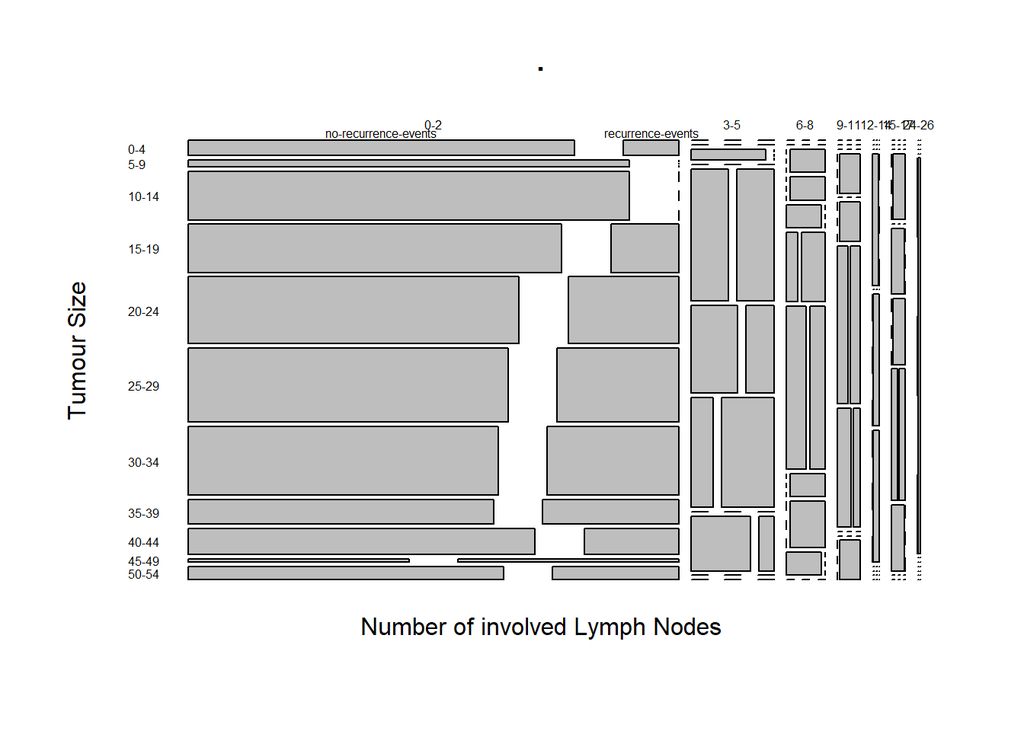

```r
table(bdata_alt$invNodes, bdata_alt$tumorSize, color = bdata$class) %>% mosaicplot(cex=0.5, xlab = "Number of involved Lymph Nodes", ylab = "Tumour Size", las=1)
```

We derive a mosaic plot to show the relationship between `tumourSize` and `invNodes`. For the majority of cases, there are fewer (0-2) lymph nodes infected, even when the tumour size is large. For other cases of `tumorSize`, there are progressively fewer lymph nodes involved. Though there may be a correlation, this is not immediately visible.

Because we also now have a data set with numeric age variables, called `mage`, we could examine the histogram of the age distribution in the data set. This shows the distribution of the average ages in the data set the nature of this distribution.

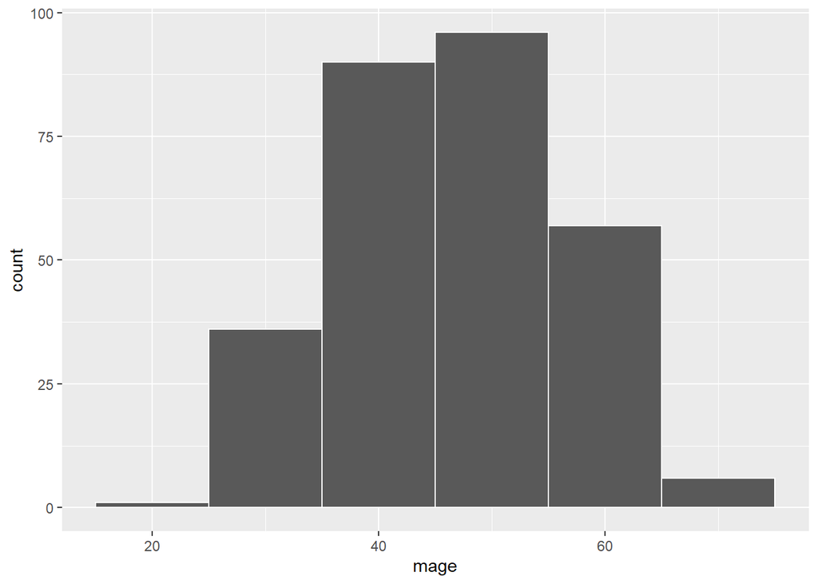

```r
#plot histogram of age distribution
bdata_malt %>% ggplot(aes(x = mage)) + geom_histogram(bins=6, color="white")
```

We are able to tell that the distibution of age in the data set appears normal. There are fewer young and old people, with most patients middle-aged.

We also examine the correlation of the average `age` with the average `tumorSize` and average `invNode`. The correlation between these variables is very weak. Perhaps we can generalize with these averages and supposed that the actual factor variables may be independent of each other.

```r
bdata_malt %>% select(mage, mtumorSize, minvNodes) %>% cor
```

```
##                   mage  mtumorSize   minvNodes
## mage        1.00000000 -0.01055947 -0.03511188
## mtumorSize -0.01055947  1.00000000  0.16048690
## minvNodes  -0.03511188  0.16048690  1.00000000
```

## Missing Values

Missing values could be a problem for any data set. This is especially true when the data set is not large, or when missing values dominate. The `breast-cancer` data set has some missing values. These are present under `nodeCaps` and `breastQuad`. While there are only few missing values (9 in all), the size of the data set means it may be important to attempt imputing these values. Since the values missing at each record are not multiple, it may be desirable to impute these missing values. This means there is sufficient information available for these records to impute their missing values. In addition, some of the missing values are present in records with cases of recurrent-events, for which we have fewer rows to begin with. As a result, it will be of benefit to our overall analysis if we could impute these values.

To do this, we will attempt a very simplistic approach at first by examining the mode of the attributes with missing values. This is the preferable method when working with categorical variables.

```r
summary(bdata[,c("nodeCaps", "breastQuad")])
```

```
##  nodeCaps       breastQuad
##  no  :222   central  : 21
##  yes : 56   left_low :110
##  NA's:  8   left_up  : 97
##             right_low: 24
##             right_up : 33
##             NA's     :  1
```

### Imputing using KNN

First, we impute missing values using kNN. One distance measure often used for categorical or mixed data is Gower distance. This measure is calculated with the following formula for two observations $p$ and $q$, over $i$ variables.

$d_{p,q} = \frac{\sum_{i=1}^{n} w_{i}d_{i}^{2}}{\sum_{i=1}^{n} w_{i}}$

where $w_{i}$ is a weight for the $i$th variable. $w_{i}$ takes the value 1 when both $p$ and $q$ are known; otherwise it takes zero. $d_{i}^2$ is the square of the distance between the $i$th value of the two observations ($p_{i}$ and $q_{i}$). $d_{i}$ is given as:

$d_{i} = \frac{{|p_{i}-q_{i}|}}{R_{i}}$

Before imputting, we take a record of the rows with missing values. We then use the five nearest neighbours of each missing value for the imputting

```r
with(bdata, which(is.na(nodeCaps) | is.na(breastQuad)))
```

```
## [1] 146 164 165 184 185 207 234 264 265
```

The indices 146, 164, 165, 184, 185, 207, 234, 264 and 265 are those with missing values in either `nodeCaps` or `breastQuad`.

```r
#Load required library
library(VIM)
#Create new dataframe and impute missing values
bdata_impute <- kNN(bdata, variable = c("nodeCaps", "breastQuad"), k = 5)

summary(bdata_impute[,c("nodeCaps", "breastQuad")])
```

```
##  nodeCaps      breastQuad
##  no :230   central  : 21
##  yes: 56   left_low :111
##            left_up  : 97
##            right_low: 24
##            right_up : 33
```

```r
bdata_impute <- subset(bdata_impute, select = class:irradiat)
```

We see from the kNN results that the missing values under `nodeCaps` have been assigned the value of “no”, while those under `breastQuad` have been assigned the value of “left_low”. This is similar to what we achieved earlier using the modal values, and may suggest that the assigned values are appropriate. As a final check, we will use MCA to examine the distribution of each of these variables, while also gaining insight into how the different attributes from the data set is distributed. This way, we will not only be able to impute the missing values, but also examine the data distribution.

### Multiple Correspondence Analysis

The attributes in this data set are all categorical. This means we cannot use R’s base PCA package. Chavent et al (2017) discuss how to handle multivariate analysis of mixed data in their paper **Multivariate Analysis of Mixed Data: The R Package PCAmixdata**. The package “extends standard multivariate analysis methods to incorporate this type of data”. It offers the function `PCAmix` which makes no distinction between ordinal and nominal variables and can be used for principal component analysis of both using MCA via Generalized Singular Value Decomposition.

```r
#Load required library
library(PCAmixdata)
#Split data into quanti and quali. There are no quanti variables here though
bdata_split <- splitmix(bdata)

X1 <- bdata_split$X.quanti
X2 <- bdata_split$X.quali

#X2 has the class variable, which we can conveniently remove
X2 <- X2[,-1]

head(X2)
```

```
##     age menopause tumorSize invNodes nodeCaps degMalig breast breastQuad
## 1 30-39   premeno     30-34      0-2       no        3   left   left_low
## 2 40-49   premeno     20-24      0-2       no        2  right   right_up
## 3 40-49   premeno     20-24      0-2       no        2   left   left_low
## 4 60-69      ge40     15-19      0-2       no        2  right    left_up
## 5 40-49   premeno       0-4      0-2       no        2  right  right_low
## 6 60-69      ge40     15-19      0-2       no        2   left   left_low
##   irradiat
## 1       no
## 2       no
## 3       no
## 4       no
## 5       no
## 6       no
```

```r
#Generate matrix
bdata.pcamix <- PCAmix(X.quali = X2, rename.level = TRUE, graph = FALSE)

head(bdata.pcamix$eig, 8)
```

```
##       Eigenvalue Proportion Cumulative
## dim 1   2.406701   7.513553   7.513553
## dim 2   1.919684   5.993120  13.506673
## dim 3   1.589588   4.962582  18.469255
## dim 4   1.478357   4.615325  23.084581
## dim 5   1.434027   4.476932  27.561513
## dim 6   1.361882   4.251700  31.813213
## dim 7   1.270875   3.967583  35.780796
## dim 8   1.218464   3.803960  39.584756
```

We are able to see the first few principal components. The first 8 dimensions retreive about 39% of the total inertia. When we plot the first two principal components and take a look at the data distribution with age for example, we see quite a fairly well distributed plot.

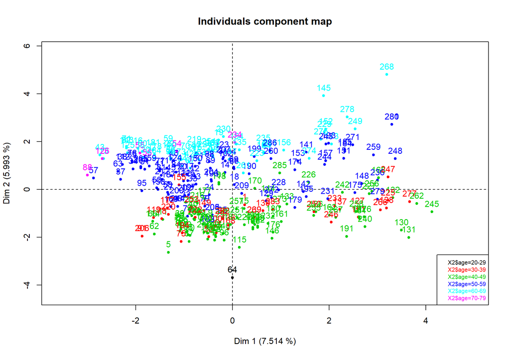

```r
#plot PCA mix
plot(bdata.pcamix, choice="ind", coloring.ind=X2$age, posleg="bottomright", cex.leg=0.7)
```

Most of the older populations are located at the top of this age distribution, while the younger population are located somewhat at the bottom. We already see some favourable distribution which gives us additional insight into the data.

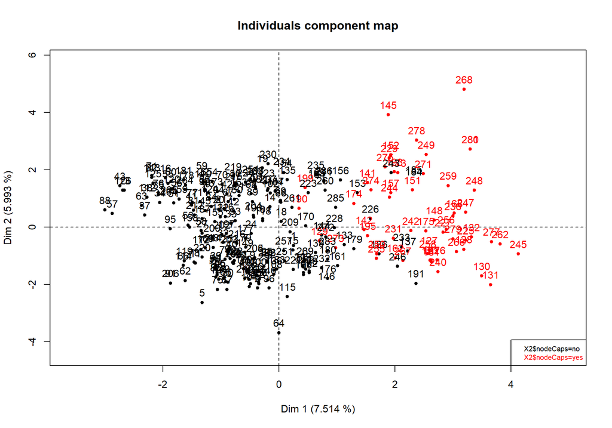

```r
#plot PCA mix
plot(bdata.pcamix, choice="ind", coloring.ind=X2$nodeCaps, posleg="bottomright", cex.leg=0.7)
```

```r
#The missing points are obtainable using
bdata.pcamix$ind$coord %>% head
```

```
##        dim 1      dim 2       dim 3      dim 4      dim 5
## 1  0.2549880 -0.6394626  1.27828248  0.6694330 -0.7406034
## 2 -0.3657660 -2.1241721 -1.63111532 -0.3814475  0.8753832
## 3 -0.5425508 -1.4853266  0.09101214 -0.9829640 -0.6310138
## 4 -1.2788742  1.2649369 -1.05433713 -0.8078283  0.2136124
## 5 -1.3227473 -2.6302924  2.38152693  0.4447967  2.4870292
## 6 -1.3029988  1.6016459  0.40761565 -0.5765526 -0.8429822
```

These are the missing indices in the original data

```r
#indices of missing items in nodeCaps
with(bdata, which(is.na(nodeCaps)))
```

```
## [1] 146 164 165 184 185 234 264 265
```

```r
#indices of missing items in breastQuad
with(bdata, which(is.na(breastQuad)))
```

```
## [1] 207
```

We could visualize the missing items in the principal components plot. When we do this we are able to see the “cluster” to which the missing items belong. **The blue dots identify the missing values.**

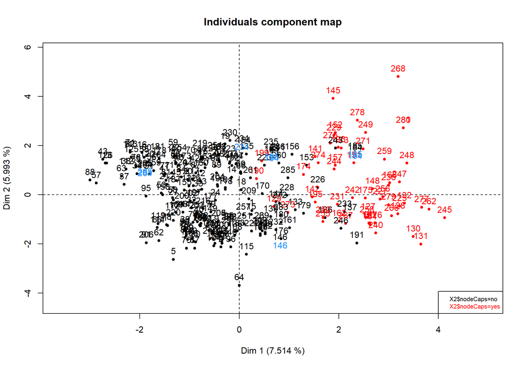

```r
#plot PCA mix
plot(bdata.pcamix, choice="ind", coloring.ind=X2$nodeCaps, posleg="bottomright", cex.leg=0.7)

#Extract items
x <- data.frame(bdata.pcamix$ind$coord[with(bdata, which(is.na(nodeCaps))),])
x$label <- with(bdata, which(is.na(nodeCaps)))

#plot points
for (i in 1:8){text(x$dim.1[i],x$dim.2[i], label=x$label[i], col="dodgerblue")}
```

When we examine the missing incides in the PCA plot, we see that most the the missing data for `nodeCaps` are grouped with the “no” cluster, while the missing value in `breastQuad` is grouped with “central”. This is a little different from what we obtained using the mode and with kNN. At the moment, we will go with the results obtained from the mode and kNN, since these agree with each other.

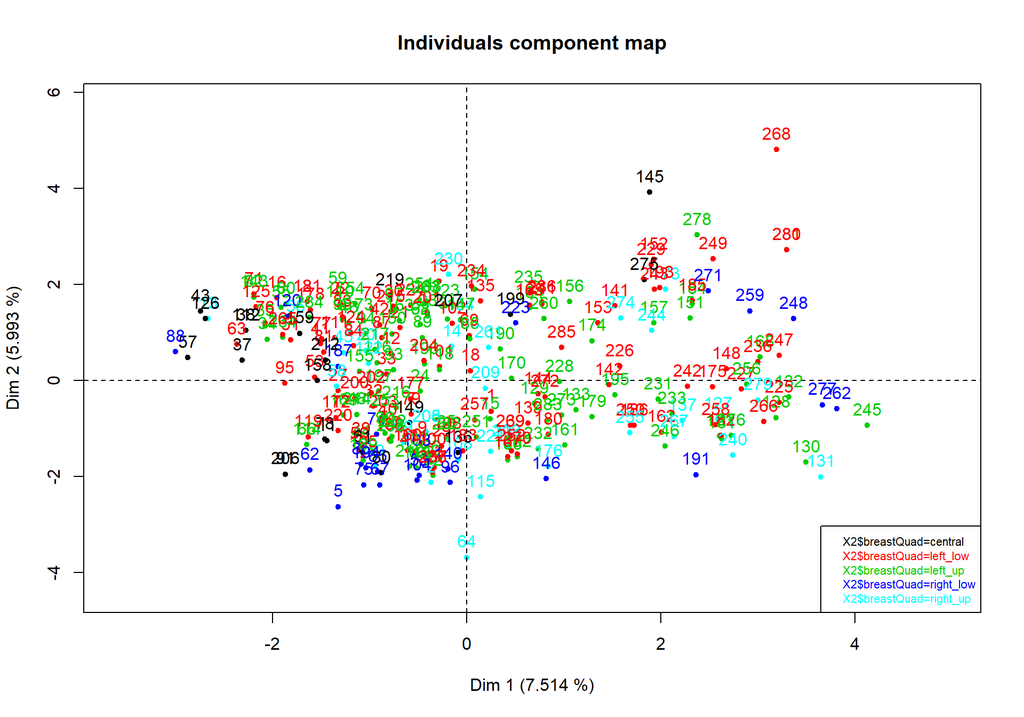

```r
plot(bdata.pcamix, choice="ind", coloring.ind=X2$breastQuad, posleg="bottomright", cex.leg=0.7)
```

Now, we imput the missing values into the original data set.

```r
bdata[which(is.na(bdata$breastQuad)), c("breastQuad")] <- summary(bdata$breastQuad) %>% which.max %>% names
```

```r
bdata[with(bdata, which(is.na(nodeCaps))), c("nodeCaps")] <- summary(bdata$nodeCaps) %>% which.max %>% names
```

Now, we examine if there are any NAs in the data set.

```r
any(is.na(bdata))
```

```
## [1] FALSE
```

We have been able to successfully fill out the missing values: `any(is.na)` returns FALSE.

## Class Balancing

When there is a disparity in the frequencies of the observed classes in a data set, fitted models can be significantly impacted. If we take, for example, an extreme case of a binary classification task where, in a sample, there are 99 cases of a positive class and 1 case of a negative task. It is pretty easy to conclude that the model will be hard pressed making negative predictions. This is especially bad if the sample is not representative of the true population. Unfortunately, our data set is skewed such that there are many more cases of non-recurrent breast cancer. We have about 29% of recurrence-events and 70% non-recurrence-events. This means we have to find a technique which helps to even the class imbalance.

```r
table(bdata$class) %>% prop.table * 100
```

```
##
## no-recurrence-events    recurrence-events
##             70.27972             29.72028
```

Achieving class balance is often done using oversampling, undersampling or synthethic data generation. Undersampling retrieves less records from the majority class and, this way, strikes a balance in the data set. This can either be done randomly or strategically. Oversampling, on the other hand, replicates observations in the minority class in the data set. Synthethic data generation adds new observations derived from the classes in the data set. This can be acheived using kNN or bootstrapping.

We can use the `ROSE` package to help with balancing the data set. We have a choice of oversampling, undersampling, both or synthethically generating new data. We will mostly go with oversampling, i.e. sampling up, since we have rather few cases of `recurrence-events` to begin with. We will also attempt variants of other sampling techniques, so that we can compare results. Some of those we will try include undersampling and synthethic data generation. As we proceed with building the model, we will evaluate the results from these methods and examine how well they do. Using both oversampling and undersampling is not uncommon. This method attempts to strike a balance between undersampling the majority class and oversampling the minority class. Synthethic data generation, on the other hand, could result in overfitting following its more robust algorithm and exceptionally high accuracy. Before applying sampling techniques, we will split the data set into training and test sets, and then randomly sample the training set. We will then test our model with the test set to assess its viability.

In order to be balanced in the train-test split, we will subset the data set and split in the desired 70/30 ratio.

```r
###################
# Class Balancing #
###################


#Load required library
library(dplyr)

#Set seed value
set.seed(80)

#Split data set into training and test sets
bdata_non_recur <- subset(bdata, class == "no-recurrence-events")
bdata_recur <- subset(bdata, class == "recurrence-events")

#Sample equally from recurrence and non-recurrence events. Split into training and test data
ind.non.recur <- sample(1:nrow(bdata_non_recur), size = floor(0.7*nrow(bdata_non_recur)))
ind.recur <- sample(1:nrow(bdata_recur), size = floor(0.7*nrow(bdata_recur)))

bdata.train <- bind_rows(bdata_non_recur[ind.non.recur,], bdata_recur[ind.recur,])
bdata.test <- bind_rows(bdata_non_recur[-ind.non.recur,], bdata_recur[-ind.recur,])

#Shuffle contents of training and test sets
train.ind <- sample(1:nrow(bdata.train), size = 1*nrow(bdata.train))
bdata.train <- bdata.train[train.ind,]

test.ind <- sample(1:nrow(bdata.test), size = 1*nrow(bdata.test))
bdata.test <- bdata.test[test.ind,]
```

The training set is still unbalanced, and we can now proceed to randomly sample the training set to achieve balance prior to fitting model.

```r
#Show class samples in training set
table(bdata.train$class)
```

```
##
## no-recurrence-events    recurrence-events
##                  140                   59
```

```r
#Load required library
library(ROSE)
#Set seed
set.seed(80)

#Oversampling and undersampling
bdata.balanced.ovun <- ovun.sample(class ~ ., data = bdata.train, method = "both", p = 0.5)
bdata.balanced.ovun <- bdata.balanced.ovun$data

#Examine distribution
table(bdata.balanced.ovun$class)
```

```
##
## no-recurrence-events    recurrence-events
##                  110                   89
```

```r
#Synthethic data generation
bdata.balanced.rose <- ROSE(class ~ ., data = bdata.train, seed = 100)$data

#Examine distribution of ROSE data set
table(bdata.balanced.rose$class)
```

```
##
## no-recurrence-events    recurrence-events
##                  100                   99
```

We have now been able to achieve a balanced data set in the training set. We have created two data sets: one generated using both oversampling and undersampling, and the other generated synthetically using Randomly Oversampling Examples (ROSE). These will be used to build all subsequent models, and we will examine how well they both do.

## Model Fitting

In this section, we conduct required classification tasks using the derived data sets. The research problem seeks to produce a model which should achieve good prediction in distinguishing between recurrent and non-recurrent cases of breast cancer. In achieving a good model, we aim to minimize the number of false negatives. False negatives (FN) are cases where a recurrent case has been wrongly classified as non-recurrent. In clinical practices, this is typically avoided, as it could be extremely traumatic for the patients involved. As a result, while conducting our analysis, we will attempt to minimize FNs.

Our classification task is comprised of four model fitting methods. First, we construct a decision tree and evaluate our test set with this. Next, we create a naive-bayes classifier and we see how well this does in comparison using the test set. Then we conduct logistic regression with the available data. Before conducting logistic regression, we will use stepwise regression to determine the best features. Finally, we will conduct classification using a neural network. During each step, cross-validation methods will be used to test the robustness of each classifier against the others. Metrics will also be collected, and as a final step in the process, the results of the different classifiers will be compared.

Our model should seek to minimize the false negatives. As `recurrence-events` will be our positive class, false negatives will represent instances of recurrence-events wrongly classified as no-recurrence-events. This will be cases of patients who run the risk of relapsing, but who are predicted by the model as not disposed to recurrence. This is especially important as we intend to avoid scenarios whereby patients are misinformed. We will also seek to improve sensitivity and precision, while deriving the appropriate ROC curves.

```r
require(jpeg)
```

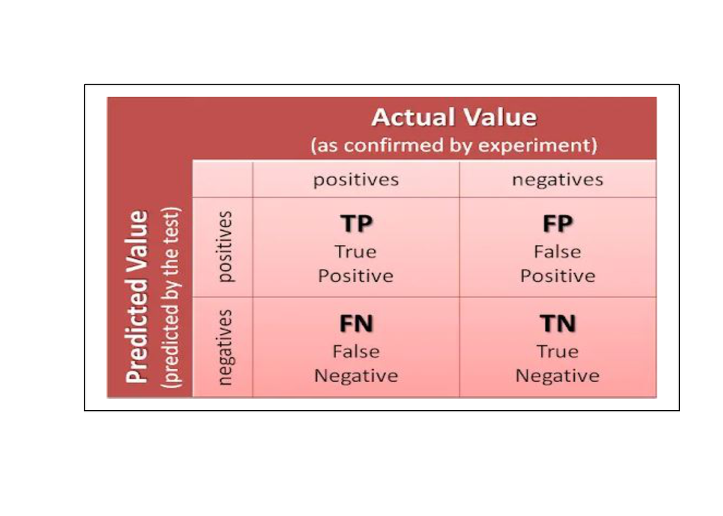

```r
img<-readJPEG("./images/contingency.jpg")
plot(1:4, ty = 'n', ann = FALSE, xaxt = 'n', yaxt = 'n')
rasterImage(img,1,1,4,4)
```

We will be using seed value of 80 to ensure consistency in all results.

### Decision Tree

Using the now balanced data set, we build a decision tree and calculate metrics. First we use the training data set, which has been over- and under-sampled with a probability of 0.5. This is an initial run to get an idea how the model does for the randomly sampled data set we created.

```r
###################################
# Model-fitting for Decision Tree #
###################################


#Set seed
set.seed(80)

#Load required library
library(partykit)
library(caret)
#Build decision tree
bdata.ctree <- ctree(class ~ ., data = bdata.balanced.ovun)

#Predict classes using test set
bdata.pred.ctree <- predict(bdata.ctree, newdata = bdata.test)

#Generate confusion matrix
confusionMatrix(bdata.pred.ctree, reference = bdata.test$class, positive="recurrence-events")
```

```
## Confusion Matrix and Statistics
##
##                       Reference
## Prediction             no-recurrence-events recurrence-events
##   no-recurrence-events                   50                15
##   recurrence-events                      11                11
##
##                Accuracy : 0.7011
##                  95% CI : (0.5935, 0.7946)
##     No Information Rate : 0.7011
##     P-Value [Acc > NIR] : 0.5527
##
##                   Kappa : 0.254
##
##  Mcnemar's Test P-Value : 0.5563
##
##             Sensitivity : 0.4231
##             Specificity : 0.8197
##          Pos Pred Value : 0.5000
##          Neg Pred Value : 0.7692
##              Prevalence : 0.2989
##          Detection Rate : 0.1264
##    Detection Prevalence : 0.2529
##       Balanced Accuracy : 0.6214
##
##        'Positive' Class : recurrence-events
##
```

This set produced the model with 15 false negatives. Its sensitivity is quite poor at a value of 42%, while the specificity is very good at 82%. Its overall accuracy is about 70%.

We re-attempt the modelling with the synthetically generated data and observe if there are any changes.

```r
#Set seed
set.seed(80)

#Load required library
library(partykit)

#Build decision tree
bdata.ctree <- ctree(class ~ ., data = bdata.balanced.rose)

#Predict classes using test set
bdata.pred.ctree <- predict(bdata.ctree, newdata = bdata.test)

#Generate confusion matrix
confusionMatrix(bdata.pred.ctree, reference = bdata.test$class, positive="recurrence-events")
```

```
## Confusion Matrix and Statistics
##
##                       Reference
## Prediction             no-recurrence-events recurrence-events
##   no-recurrence-events                   44                11
##   recurrence-events                      17                15
##
##                Accuracy : 0.6782
##                  95% CI : (0.5694, 0.7744)
##     No Information Rate : 0.7011
##     P-Value [Acc > NIR] : 0.7243
##
##                   Kappa : 0.2797
##
##  Mcnemar's Test P-Value : 0.3447
##
##             Sensitivity : 0.5769
##             Specificity : 0.7213
##          Pos Pred Value : 0.4688
##          Neg Pred Value : 0.8000
##              Prevalence : 0.2989
##          Detection Rate : 0.1724
##    Detection Prevalence : 0.3678
##       Balanced Accuracy : 0.6491
##
##        'Positive' Class : recurrence-events
##
```

The tree prioritizes `nodeCaps` as the attribute with the highest information again, hence it is the root node. The next most important feature appears to be `degMalig`. Other features did not appear to be as important in decision making. **It turns out the number of infected lymph nodes and the histological grade of the tumor are rather strong determinants of the recurrence of breast cancer in women**. This is consistent with results obtained from cancer researches (Mayo Clinic, 2020).

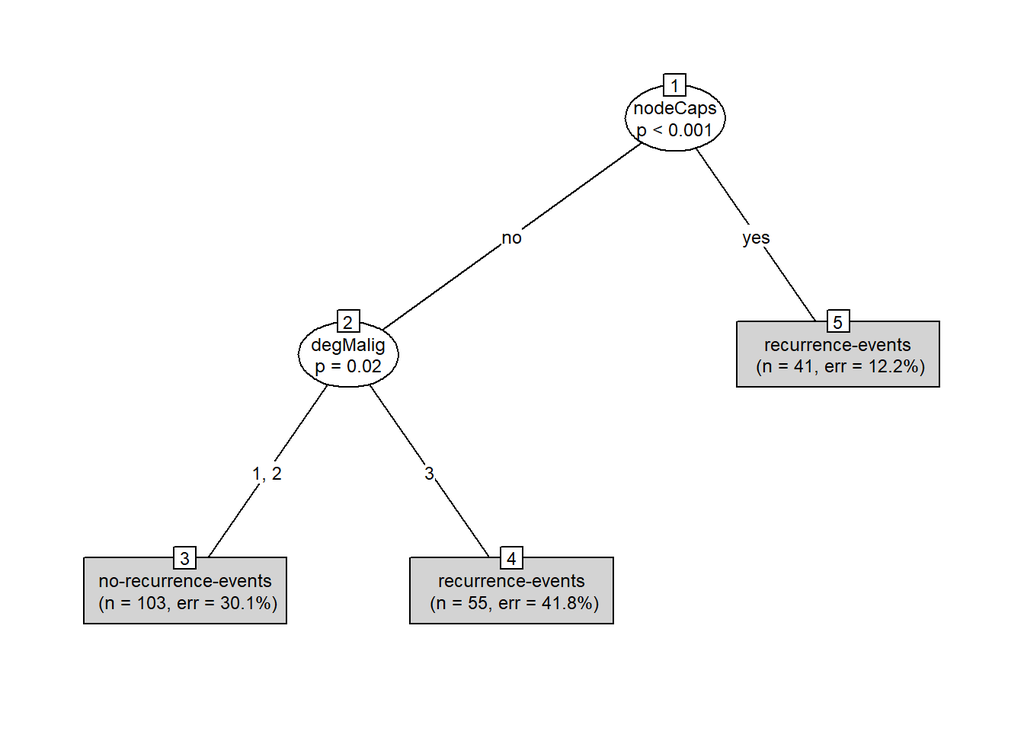

```r
plot(bdata.ctree, type = "simple", gp = gpar(fontsize = 9))
```

Now, for the cross-validation using decision trees, we use `caret` to achieve this objective, while using the provided functionality to sample up:

```r
######################################
# Cross-Validation for Decision Tree #
######################################


#set seed
set.seed(80)

#Load required libraries
library(rpart)
library(caret)

#Set hyperparameters
trnControl <- trainControl(method = "cv", sampling="up")

#Construct model
bdata.ctree.caret <- train(class ~ ., data = bdata.train, method = "ctree", trControl = trnControl)

bdata.ctree.caret
```

```
## Conditional Inference Tree
##
## 199 samples
##   9 predictor
##   2 classes: 'no-recurrence-events', 'recurrence-events'
##
## No pre-processing
## Resampling: Cross-Validated (10 fold)
## Summary of sample sizes: 179, 179, 179, 179, 179, 179, ...
## Addtional sampling using up-sampling
##
## Resampling results across tuning parameters:
##
##   mincriterion  Accuracy   Kappa
##   0.01          0.6789474  0.2742815
##   0.50          0.6992105  0.2626851
##   0.99          0.7242105  0.3527627
##
## Accuracy was used to select the optimal model using the largest value.
## The final value used for the model was mincriterion = 0.99.
```

```r
bdata.ctree.caret$resample
```

```
##     Accuracy      Kappa Resample
## 1  0.4000000 -0.2000000   Fold02
## 2  0.6500000  0.2708333   Fold01
## 3  0.9000000  0.7826087   Fold03
## 4  0.6500000  0.1250000   Fold06
## 5  0.7000000  0.2105263   Fold05
## 6  0.7500000  0.4318182   Fold04
## 7  0.8000000  0.5652174   Fold07
## 8  0.8500000  0.6590909   Fold10
## 9  0.8421053  0.5648855   Fold09
## 10 0.7000000  0.1176471   Fold08
```

```r
bdata.ctree.caret$resample$Accuracy %>% mean
```

```
## [1] 0.7242105
```

Given the imbalance in the test data set, if we predicted “no-recurrence-events” for every case in the test data, we will still be right about 70% of the time. So, this mean value isn’t really an excellent performance for the model. It performs just as well as random guessing. However, the model states quite emphatically that number of infected lymph nodes and the histological grade of the tumor are rather strong determinants of the recurrence of breast cancer in women. We derive this from our decision tree, and can conclude this is one of the better insights the model supplies.

```r
predict(bdata.ctree.caret, newdata = bdata.test) %>% confusionMatrix(reference = bdata.test$class, positive="recurrence-events")
```

```
## Confusion Matrix and Statistics
##
##                       Reference
## Prediction             no-recurrence-events recurrence-events
##   no-recurrence-events                   54                18
##   recurrence-events                       7                 8
##
##                Accuracy : 0.7126
##                  95% CI : (0.6057, 0.8046)
##     No Information Rate : 0.7011
##     P-Value [Acc > NIR] : 0.4596
##
##                   Kappa : 0.2196
##
##  Mcnemar's Test P-Value : 0.0455
##
##             Sensitivity : 0.30769
##             Specificity : 0.88525
##          Pos Pred Value : 0.53333
##          Neg Pred Value : 0.75000
##              Prevalence : 0.29885
##          Detection Rate : 0.09195
##    Detection Prevalence : 0.17241
##       Balanced Accuracy : 0.59647
##
##        'Positive' Class : recurrence-events
##
```

Using the results of the cross-validation, we again get quite good specificity and accuracy, but poor sensitivity. The false negatives increased to 18. We sampled up in building this model.

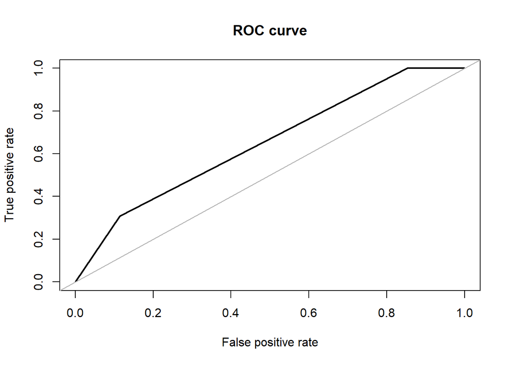

```
## Area under the curve (AUC): 0.648
```

```r
roc.curve(bdata.test$class, predict(bdata.ctree.caret, newdata = bdata.test, type = "prob")[,2])
```

### Naive-Bayes

As a second model, we construct a naive-bayes classifier with the available training data set. A naive-Bayes classifier is a probabilistic classifier which applies Bayes’s theorem while maintaining strong independence of features. This is the naive component in the classifier. It assumes that each of the features are strongly independent from each other, even though this is not always true. Even though this assumption could be extremely “naive” or oversimplified, the algorithm still works fairly well with most data sets, even if there is some correlation. For categorical variables, it is a straightforward multiplication of observed data frequency.

Here, we will train with the doubly-sampled data set, `bdata.balanced.ovun` data set before testing with the test data. We will then use `caret` to sample up in a second attempt at training and testing. Afterwards, we use `caret` to compare the results of the different randomly sampled methods. In the end, we will compare the resultant metrics to that obtained earlier using decision tree.

We start out first with training using `bdata.balanced.ovun`. We will use the training control parameters from the previous model, as this doesn’t have to change.

```r
###############################
# Model-fitting (Naive-Bayes) #
###############################

#set seed
set.seed(80)

#Create model
bdata.nb <- train(x = bdata.balanced.ovun[,-1],
                  y = bdata.balanced.ovun$class,
                  method = "nb",
                  trControl = trnControl)
```

We examine the folds and their respective accuracies:

```r
bdata.nb$resample
```

```
##     Accuracy     Kappa Resample
## 1  0.8000000 0.5959596   Fold01
## 2  0.7500000 0.5000000   Fold02
## 3  0.7500000 0.4897959   Fold03
## 4  0.5500000 0.0625000   Fold04
## 5  0.8000000 0.5959596   Fold05
## 6  0.8947368 0.7764706   Fold06
## 7  0.7500000 0.5098039   Fold07
## 8  0.7000000 0.3684211   Fold08
## 9  0.6500000 0.2708333   Fold09
## 10 0.8000000 0.5959596   Fold10
```

This time, we have accuracies for the folds ranging from 0.55 to 0.89. Now, we make predictions with the available test data.

```r
predict(bdata.nb, newdata = bdata.test) %>% confusionMatrix(reference = bdata.test$class, positive = "recurrence-events")
```

```
## Confusion Matrix and Statistics
##
##                       Reference
## Prediction             no-recurrence-events recurrence-events
##   no-recurrence-events                   50                12
##   recurrence-events                      11                14
##
##                Accuracy : 0.7356
##                  95% CI : (0.6302, 0.8245)
##     No Information Rate : 0.7011
##     P-Value [Acc > NIR] : 0.2827
##
##                   Kappa : 0.3621
##
##  Mcnemar's Test P-Value : 1.0000
##
##             Sensitivity : 0.5385
##             Specificity : 0.8197
##          Pos Pred Value : 0.5600
##          Neg Pred Value : 0.8065
##              Prevalence : 0.2989
##          Detection Rate : 0.1609
##    Detection Prevalence : 0.2874
##       Balanced Accuracy : 0.6791
##
##        'Positive' Class : recurrence-events
##
```

The accuracy is about 73%, which is higher than random selection. We observe that the specificity is quite high at about 82%. This means the false positives are appreciably low compared to the true negatives. Most of the predictions for “no-recurrence-events” were correctly identified by the model. However, the sensitivity (or recall) is still rather low at 53%. This means there is a sizeable number of false negatives relative to the number of true positives. Though the false negatives are only 12, the number of true positives at 14 ensures that the sensitivity is low. Though we have an overall low value of sensitivity (or recall), we still achieve our aim somewhat with this model since the number of false negatives is quite low.

We rebuild our model by sampling up using `caret`. We do not have to do this independently, but could have the `train` function automatically handle the sampling. Although this should make no difference, it appears to influence the sensitivity values when repeated. So, we will set a seed value.

```r
##########################################
# Cross-Validation for Naive-Bayes Model #
##########################################

#set seed
set.seed(80)

#Using caret's down sampling
#Create model
bdata.nb.caret <- caret::train(x = as.data.frame(bdata.train[,-1]), y=bdata.train$class, method="nb", trControl=trainControl(method="cv", sampling="up"))

#Predict classes and create confusion matrix
predict(bdata.nb.caret, newdata = bdata.test) %>% confusionMatrix(bdata.test$class, positive = "recurrence-events")
```

```
## Confusion Matrix and Statistics
##
##                       Reference
## Prediction             no-recurrence-events recurrence-events
##   no-recurrence-events                   50                12
##   recurrence-events                      11                14
##
##                Accuracy : 0.7356
##                  95% CI : (0.6302, 0.8245)
##     No Information Rate : 0.7011
##     P-Value [Acc > NIR] : 0.2827
##
##                   Kappa : 0.3621
##
##  Mcnemar's Test P-Value : 1.0000
##
##             Sensitivity : 0.5385
##             Specificity : 0.8197
##          Pos Pred Value : 0.5600
##          Neg Pred Value : 0.8065
##              Prevalence : 0.2989
##          Detection Rate : 0.1609
##    Detection Prevalence : 0.2874
##       Balanced Accuracy : 0.6791
##
##        'Positive' Class : recurrence-events
##
```

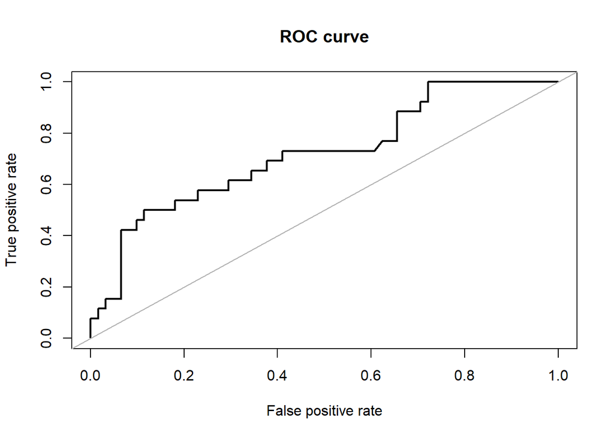

```
## Area under the curve (AUC): 0.720
```

```r
##################
# Plot ROC Curve #
##################

roc.curve(bdata.test$class, predict(bdata.nb.caret, newdata = bdata.test, type = "prob")[,2])
```

In other to improve the sensitivity of the model, we need to take an alternative approach. We take a closer look at our features and realize that some are better contributors to the model accuracy than others. Firstly, we create a combination of all possible two-feature model and then obtain the respective sensitivities for all two features. This could give an idea of which features in the data set could improve our sensitivity. We will be sampling up as we have done in previous analyses.

```r
##############################
# Check feature combinations #
##############################

#Set seed
set.seed(80)

#Create all possible combinations of two features
comb.mat <- gtools::combinations(9,2,2:10)

#Create copies of training and test sets
bdata.train.check <- bdata.train
bdata.test.check <- bdata.test

#Initialize container
df.sens.spec <- rep(0,36)

#Repeat test by sampling up
for (i in 1:36){
  bdata.caret.sens <- caret::train(x = as.data.frame(bdata.train.check[,comb.mat[i,]]), y = bdata.train.check$class, method = "nb", trControl = trainControl(method = "cv", sampling = "up"))
  df.sens.spec[i] <- sensitivity(predict(bdata.caret.sens, newdata = bdata.test.check), reference = bdata.test$class, positive = "recurrence-events")

}

df.sens.spec
```

```
##  [1] 0.1153846 0.7307692 0.3076923 0.3846154 0.4615385 0.5384615 0.6538462
##  [8] 0.2307692 0.4230769 0.2692308 0.3076923 0.4230769 0.5000000 0.6923077
## [15] 0.2307692 0.5384615 0.4615385 0.5384615 0.7307692 0.6538462 0.3846154
## [22] 0.3076923 0.4230769 0.2692308 0.5000000 0.3076923 0.5769231 0.3076923
## [29] 0.3846154 0.4230769 0.4230769 0.5384615 0.5384615 0.6923077 0.2307692
## [36] 0.3846154
```

```r
mat.out <- cbind(df.sens.spec, comb.mat)
mat.out
```

```
##       df.sens.spec
##  [1,]    0.1153846 2  3
##  [2,]    0.7307692 2  4
##  [3,]    0.3076923 2  5
##  [4,]    0.3846154 2  6
##  [5,]    0.4615385 2  7
##  [6,]    0.5384615 2  8
##  [7,]    0.6538462 2  9
##  [8,]    0.2307692 2 10
##  [9,]    0.4230769 3  4
## [10,]    0.2692308 3  5
## [11,]    0.3076923 3  6
## [12,]    0.4230769 3  7
## [13,]    0.5000000 3  8
## [14,]    0.6923077 3  9
```

[output cut: 22 more lines]

```r
mat.out[which.max(mat.out[,1]), c(2,3)]
```

```
##
## 2 4
```

We see that features 2 and 4 seemed to contribute significantly to the model’s sensitivity. These are features `age` and `tumorSize`. This means we could attempt utilizing features 2 and 4 in a new model and see if this fits well with our test data. It should be noted that this step is merely exploratory in nature.

```r
set.seed(80)

caret::train(x = as.data.frame(bdata.train.check[,c(2,4)]), y=bdata.train.check$class, method="nb", trControl=trainControl(method="cv", sampling="down")) %>%
  predict(newdata = bdata.test.check) %>%
  confusionMatrix(bdata.test.check$class, positive = "recurrence-events")
```

```
## Confusion Matrix and Statistics
##
##                       Reference
## Prediction             no-recurrence-events recurrence-events
##   no-recurrence-events                   44                10
##   recurrence-events                      17                16
##
##                Accuracy : 0.6897
##                  95% CI : (0.5814, 0.7845)
##     No Information Rate : 0.7011
##     P-Value [Acc > NIR] : 0.6424
##
##                   Kappa : 0.3126
##
##  Mcnemar's Test P-Value : 0.2482
##
##             Sensitivity : 0.6154
##             Specificity : 0.7213
##          Pos Pred Value : 0.4848
##          Neg Pred Value : 0.8148
##              Prevalence : 0.2989
##          Detection Rate : 0.1839
##    Detection Prevalence : 0.3793
##       Balanced Accuracy : 0.6683
##
##        'Positive' Class : recurrence-events
##
```

Using only features 2 and 4, we are able to improve some of the model’s parameters. We also minimized false negatives to a very low value at 10. This is exactly our objective, as we are looking to ensure there are very little cases of people with possible recurrence-events who are wrongly categorized as no-recurrence-events. We have been able to achieve this using the naive-Bayes model. The specificy and sensitivity values look okay, while the model accuracy also ranges around 69%. We may be inclined to further investigate this later.

The randomly sampling method chosen appears to have an impact on the model’s accuracy. In the naive-bayes analysis so far, we have used “up” sampling, which is a method of oversampling and which enables our fewer `recurrence-events` class to match up to the `no-recurrence-events` class. We have also combined sampling up and sampling down. Both appeared to produce similar results. Now, we check just how the different sampling methods affect the model accuracy. While the accuracy for “rose” method seemed good, the sensitivity obtained using this sampling method wasn’t very good.

```r
#########################################
# Compare different sampling techniques #
#########################################

#Set seed
set.seed(80)

#Conduct down sampling
bdata.nb.down <- caret::train(x = as.data.frame(as.data.frame(bdata.train[,-1])), y=bdata.train$class, method="nb", trControl=trainControl(method="cv", sampling="down"))
#Conduct up sampling
bdata.nb.up <- caret::train(x = as.data.frame(as.data.frame(bdata.train[,-1])), y=bdata.train$class, method="nb", trControl=trainControl(method="cv", sampling="up"))

#Conduct rose sampling
bdata.nb.rose <- caret::train(x = as.data.frame(as.data.frame(bdata.train[,-1])), y=bdata.train$class, method="nb", trControl=trainControl(method="cv", sampling="rose"))

#Conduct smote sampling
bdata.nb.smote <- caret::train(x = as.data.frame(as.data.frame(bdata.train[,-1])), y=bdata.train$class, method="nb", trControl=trainControl(method="cv", sampling="smote"))
```

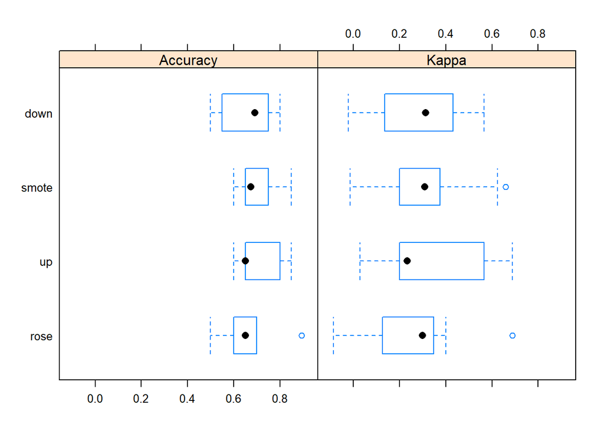

```r
bdata.models <- list(down = bdata.nb.down,
                     up = bdata.nb.up,
                     rose = bdata.nb.rose,
                     smote = bdata.nb.smote)

resamples(bdata.models) %>% bwplot
```

The plot above shows just how the different sampling techniques affect model accuracy. Though overall, they all produce an accuracy above 60%, “sampling up” seems to have greater tendency to produce better accuracy values. “Sampling down” is greater disposed to producing lower accuracy models.

For other models, we will take the approach of sampling up, as this seems to produce much better results.

In then next section, we consider using logistic regression.

### Logistic Regression

Logistic regression is another classification method which predicts a qualitative response variable. It uses a logit transformation to keep the probabilities of occurence of the response between 0 and 1. It is also a linear model. While the response is usually categorical, the predictors could be categorical, numerical or a mix of both. In our data set, we have all categorical variables, and a categorical response. This makes logistic regression quite a useful model in predicting the outcome of the response variable. In addition, it can provide us probability values which give a sense of how likely the response is. Combining this with the result, we can say with the calculated level of certainty how likely it is for breast cancer to recur in a patient.

Before building the regression model, we will first conduct backward elimination on the features in the training data set. This will provide us with an idea of the features which are the most important for our analysis, i.e. the ones which should improve our desired metric.

```r
################################
# Conduct step-wise regression #
################################

#Set seed
set.seed(80)

#Load required library
library(MASS)
#Conduct backward elimination
full <- glm(class ~ ., data = bdata, family = "binomial")
null <- glm(class ~ 1, data = bdata, family="binomial")
stepF <- stepAIC(full, direction = "backward", trace = TRUE)
```

```
## Start:  AIC=344.36
## class ~ age + menopause + tumorSize + invNodes + nodeCaps + degMalig +
##     breast + breastQuad + irradiat
##
##              Df Deviance    AIC
## - invNodes    6   282.31 336.32
## - tumorSize  10   290.66 336.66
## - age         5   281.77 337.77
## - breastQuad  4   281.43 339.43
## - menopause   2   279.96 341.96
## - nodeCaps    1   279.20 343.20
## - irradiat    1   279.24 343.24
## - breast      1   279.72 343.72
## <none>            278.36 344.36
## - degMalig    2   293.99 355.99
##
## Step:  AIC=336.32
## class ~ age + menopause + tumorSize + nodeCaps + degMalig + breast +
##     breastQuad + irradiat
##
##              Df Deviance    AIC
## - tumorSize  10   295.52 329.52
## - age         5   285.97 329.97
## - breastQuad  4   285.43 331.43
## - menopause   2   283.27 333.27
## - breast      1   283.46 335.46
## <none>            282.31 336.32
## - irradiat    1   284.80 336.80
## - nodeCaps    1   288.90 340.90
## - degMalig    2   299.24 349.24
##
## Step:  AIC=329.52
## class ~ age + menopause + nodeCaps + degMalig + breast + breastQuad +
##     irradiat
##
##              Df Deviance    AIC
## - age         5   298.62 322.62
## - breastQuad  4   298.96 324.96
## - menopause   2   296.40 326.40
## - breast      1   296.28 328.28
```

[output cut: 32 more lines]

```
##            Df Deviance    AIC
## - breast    1   304.29 314.29
## <none>          303.72 315.72
## - irradiat  1   306.54 316.54
## - nodeCaps  1   311.29 321.29
## - degMalig  2   322.77 330.77
##
## Step:  AIC=314.29
## class ~ nodeCaps + degMalig + irradiat
##
##            Df Deviance    AIC
## <none>          304.29 314.29
## - irradiat  1   307.00 315.00
## - nodeCaps  1   311.80 319.80
## - degMalig  2   323.86 329.86
```

After conducting backward elimination, we see that the most significant features appear to be `nodeCaps`, `degMalig` and `irradiat`.

```r
glm(class ~ nodeCaps + degMalig + irradiat, data = bdata, family = "binomial") %>% summary
```

```
##
## Call:
## glm(formula = class ~ nodeCaps + degMalig + irradiat, family = "binomial",
##     data = bdata)
##
## Deviance Residuals:
##     Min       1Q   Median       3Q      Max
## -1.6705  -0.7422  -0.5826   0.9463   1.9274
##
## Coefficients:
##             Estimate Std. Error z value Pr(>|z|)
## (Intercept) -1.65453    0.32026  -5.166 2.39e-07 ***
## nodeCapsyes  0.95873    0.35000   2.739  0.00616 **
## degMalig2   -0.03314    0.40093  -0.083  0.93412
## degMalig3    1.26722    0.40614   3.120  0.00181 **
## irradiatyes  0.53922    0.32464   1.661  0.09672 .
## ---
## Signif. codes:  0 '***' 0.001 '**' 0.01 '*' 0.05 '.' 0.1 ' ' 1
##
## (Dispersion parameter for binomial family taken to be 1)
##
##     Null deviance: 348.05  on 285  degrees of freedom
## Residual deviance: 304.29  on 281  degrees of freedom
## AIC: 314.29
##
## Number of Fisher Scoring iterations: 3
```

After using these three predictors to build a logistic regression model, we obtain the output above by calling the `summary` function. This suggests that the log of the odds of experiencing breast cancer recurrence increases by 0.95873 when `nodeCaps` is a yes, i.e. if the cancer metastasized into a lymph node. This is after controlling for all other predictors. This result is consistent with findings from cancer research. Additionally, the summary output suggests that the log of the odds of experiencing breast cancer recurrence increases by 1.26722 if the histological grade of the cancer is a 3, after controlling for all other predictors. Similarly, the risk of a recurrence is higher if the patient has been received irradiation as treatment.

We will first attempt to build the model using only these features, assess the quality of the model, and then reattempt same with all the features. This way we can observe if there are any differences in the constructed models. This time we will use the formula format in the `train` function.

```r
#set seed
set.seed(80)

#Build logistic regression model from identified features
bdata.glm.caret <- train(class ~ nodeCaps + degMalig + irradiat,
      data = bdata.train,
      method = "glm",
      family = "binomial",
      trControl = trainControl(method = "cv", number = 10, sampling = "up"))

bdata.glm.caret %>%
  predict(newdata = bdata.test) %>% confusionMatrix(reference=bdata.test$class, positive="recurrence-events")
```

```
## Confusion Matrix and Statistics
##
##                       Reference
## Prediction             no-recurrence-events recurrence-events
##   no-recurrence-events                   47                13
##   recurrence-events                      14                13
##
##                Accuracy : 0.6897
##                  95% CI : (0.5814, 0.7845)
##     No Information Rate : 0.7011
##     P-Value [Acc > NIR] : 0.6424
##
##                   Kappa : 0.2675
##
##  Mcnemar's Test P-Value : 1.0000
##
##             Sensitivity : 0.5000
##             Specificity : 0.7705
##          Pos Pred Value : 0.4815
##          Neg Pred Value : 0.7833
##              Prevalence : 0.2989
##          Detection Rate : 0.1494
##    Detection Prevalence : 0.3103
##       Balanced Accuracy : 0.6352
##
##        'Positive' Class : recurrence-events
##
```

The model did only as good as the previous two. The sensitivity is around 50%, while the specificity is about 78%. There are a handful of false negatives, which is misleading for our results. The model accuracy, however, seems is only 69%. We have used up-sampling available in `caret` to achieve class balance. When the model is retried with `bdata.balanced.ovun`, it yields nearly the same metrics. In this case, changing sampling techniques did not improve our results.

Now, we reattempt with all of the features from the training set.

```r
#set seed
set.seed(80)

#Build logistic regression model from identified features
train(class ~ .,
      data = bdata.train,
      method = "glm",
      family = "binomial",
      trControl = trainControl(method = "cv", number = 10, sampling = "up")) %>%
  predict(newdata = bdata.test) %>% confusionMatrix(reference=bdata.test$class, positive="recurrence-events")
```

[output not shown]

```
## Confusion Matrix and Statistics
##
##                       Reference
## Prediction             no-recurrence-events recurrence-events
##   no-recurrence-events                   46                14
##   recurrence-events                      15                12
##
##                Accuracy : 0.6667
##                  95% CI : (0.5575, 0.7642)
##     No Information Rate : 0.7011
##     P-Value [Acc > NIR] : 0.7953
##
##                   Kappa : 0.2133
##
##  Mcnemar's Test P-Value : 1.0000
##
##             Sensitivity : 0.4615
##             Specificity : 0.7541
##          Pos Pred Value : 0.4444
##          Neg Pred Value : 0.7667
##              Prevalence : 0.2989
##          Detection Rate : 0.1379
##    Detection Prevalence : 0.3103
##       Balanced Accuracy : 0.6078
##
##        'Positive' Class : recurrence-events
##
```

Using all of the predictors did not seem to change things very much. The sensitivity is still rather low, though the specificity is quite good. This means we were, in fact, better off using only the three predictors from the first model, i.e. `nodeCaps`, `degMalig` and `irradiat`. These features seem to deliver the best metrics for the data set. Alternatively, if we intend to minize the false negatives, we may go with features 2 and 4 as earlier shown. Though they seem to deliver the best sensitivity values, we may still need additional analysis to verify their substance.

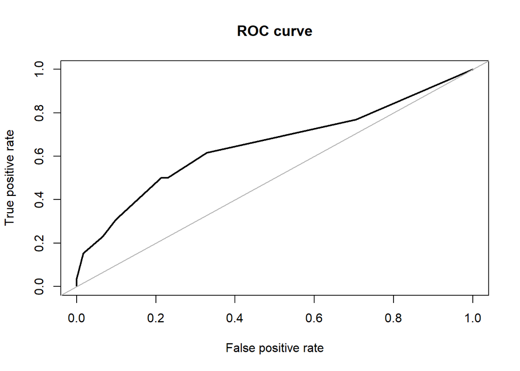

```
## Area under the curve (AUC): 0.651
```

```r
roc.curve(bdata.test$class, predict(bdata.glm.caret, newdata = bdata.test, type = "prob")[,2])
```

### Artificial Neural Networks

Influenced by the biological neuron, neural networks learn by example. They provide learning techniques that are able to interpret even complex data, generalizing to multiple scenarios if required. Artificial neural networks can approximate a lot of function, no matter how complicated. They are modeled after the human brain, which is an interconnected web of neurons transmitting electrical signals around the body. Using this model, neurons, arranged in a series of layers, are designed to receive external information which is run through a series of hidden layers to produce an output. All of the layers, including the input and output units, are all connected, with connections between units represented as weights. Higher weights have more influence; lower weights less influence. Advances in computing power has made neural networks a reality in the modern day, so that millions of calculations which they require can be run on the most basic processors.

The `caret` package allows the use of `nnet` in the creation of a model. We could assess the `nnet` package through this means in our training of a neural network for classification purposes. We set the weight decay and size using the combination specified under `netgrid`.

```r
##################
# Neural Network #
##################

#set seed
set.seed(80)

#Copy training and test data
bdata.df.nnet.train <- bdata.train
bdata.df.nnet.test <- bdata.test

#specifiy training parameters
trControl <- trainControl(method="cv",
                          number=10,
                          classProbs = TRUE,
                          summaryFunction = twoClassSummary,
                          sampling = "up")

#Define size and decay
netgrid <- expand.grid(size = seq(1,10,1),
                       decay = seq(0.1,0.5,0.1))

#Create model
bdata.nnet <- train(make.names(class) ~., data=bdata.df.nnet.train,method="nnet",
                    metric="ROC",trControl=trControl,
                    tuneGrid=netgrid,
                    verbose=FALSE, trace=FALSE)
```

```r
print(bdata.nnet)
```

```
## Neural Network
##
## 199 samples
##   9 predictor
##   2 classes: 'no.recurrence.events', 'recurrence.events'
##
## No pre-processing
## Resampling: Cross-Validated (10 fold)
## Summary of sample sizes: 179, 179, 179, 179, 179, 179, ...
## Addtional sampling using up-sampling
##
## Resampling results across tuning parameters:
##
##   size  decay  ROC        Sens       Spec
##    1    0.1    0.6147619  0.7142857  0.4733333
```

[output cut: 52 more lines]

First, we check the metrics of the neural network with the training data set.

```r
predict(bdata.nnet, newdata=bdata.df.nnet.train) %>% confusionMatrix(reference=as.factor(make.names(bdata.df.nnet.train$class)), positive="recurrence.events")
```

```
## Confusion Matrix and Statistics
##
##                       Reference
## Prediction             no.recurrence.events recurrence.events
##   no.recurrence.events                  111                19
##   recurrence.events                      29                40
##
##                Accuracy : 0.7588
##                  95% CI : (0.6932, 0.8165)
##     No Information Rate : 0.7035
##     P-Value [Acc > NIR] : 0.04952
##
##                   Kappa : 0.4488
##
##  Mcnemar's Test P-Value : 0.19393
##
##             Sensitivity : 0.6780
##             Specificity : 0.7929
##          Pos Pred Value : 0.5797
##          Neg Pred Value : 0.8538
##              Prevalence : 0.2965
##          Detection Rate : 0.2010
##    Detection Prevalence : 0.3467
##       Balanced Accuracy : 0.7354
##
##        'Positive' Class : recurrence.events
##
```

The output appears good. With an accuracy of about 76%, a sensivity of 67% and specificity of nearly 80%, the model appears good on the training data set. This is not surprising however, since the model has seen this data once. Checking with the training set allows us to gain an insight into how the model will report on data it has not seen before by looking at how it does on data it has seen previously.

Now, we check its metrics with the test set.

```r
predict(bdata.nnet, newdata=bdata.df.nnet.test) %>% confusionMatrix(reference=as.factor(make.names(bdata.df.nnet.test$class)), positive="recurrence.events")
```

```
## Confusion Matrix and Statistics
##
##                       Reference
## Prediction             no.recurrence.events recurrence.events
##   no.recurrence.events                   49                13
##   recurrence.events                      12                13
##
##                Accuracy : 0.7126
##                  95% CI : (0.6057, 0.8046)
##     No Information Rate : 0.7011
##     P-Value [Acc > NIR] : 0.4596
##
##                   Kappa : 0.3067
##
##  Mcnemar's Test P-Value : 1.0000
##
##             Sensitivity : 0.5000
##             Specificity : 0.8033
##          Pos Pred Value : 0.5200
##          Neg Pred Value : 0.7903
##              Prevalence : 0.2989
##          Detection Rate : 0.1494
##    Detection Prevalence : 0.2874
##       Balanced Accuracy : 0.6516
##
##        'Positive' Class : recurrence.events
##
```

We also generate `bdata.nnet.caret` with which we will compare accuracy with other models.

```r
#set seed
set.seed(80)

#Create model
bdata.nnet.caret <- train(class ~ .,
      data = bdata.df.nnet.train,
      method = "nnet",
      trControl = trainControl(method = "cv", number = 10, sampling = "up"), trace = FALSE)
```

We can generate a plot of the features important to the classification algorithm.

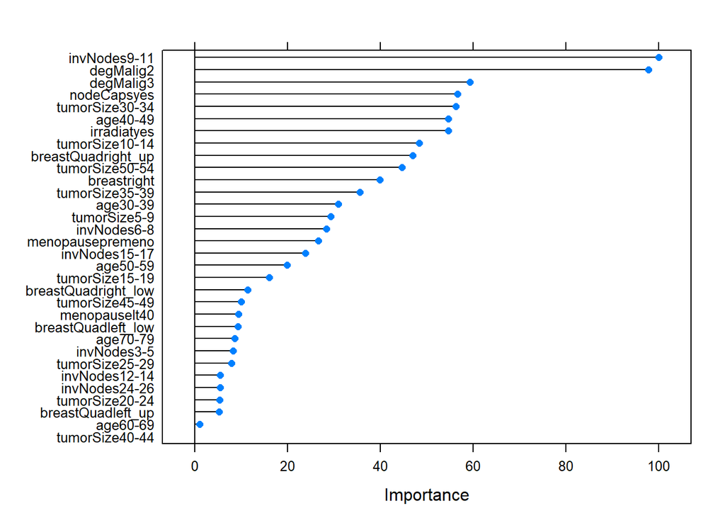

```r
#Plot variable importance
plot(varImp(bdata.nnet))
```

We can also generate a plot of the neural net.

```r
library(NeuralNetTools)
```

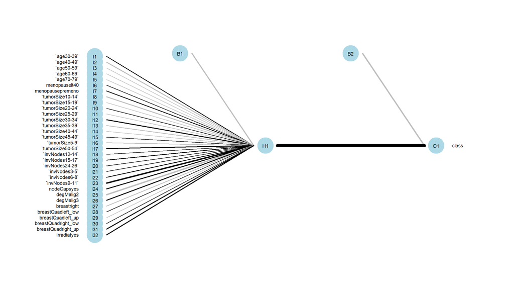

```r
plotnet(bdata.nnet$finalModel, y_names="class", cex=0.7)
```

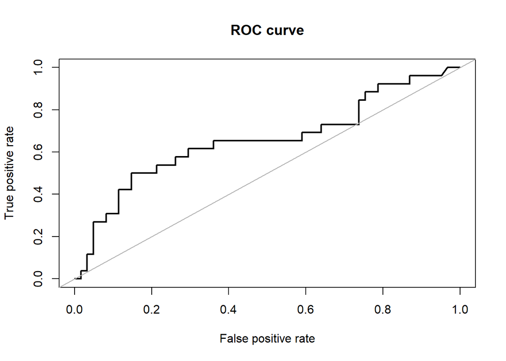

```
## Area under the curve (AUC): 0.656
```

```r
roc.curve(bdata.df.nnet.test$class, predict(bdata.nnet, newdata=bdata.df.nnet.test, type = "prob")[,2])
```

## Feature Engineering

We intend to investigate just how good the identified features may be in fitting any model. These are dummy features and are only a subset of the main features. However, we will be checking how well using these features may help with any of our models. If they are important features, shouldn’t they produce the best output?

First we shuffle the indices in `bdata` which was originally created from stacks of input data.

```r
#set seed
set.seed(80)

#Shuffled main dataframe
ind.shuf <- sample(1:nrow(bdata), size = 1*nrow(bdata))
bdata.shuffled <- bdata[ind.shuf,]

nrow(bdata.shuffled) == nrow(bdata)
```

```
## [1] TRUE
```

To conduct a classification task, a neural network will usually require dummy variables. When we look at the plot of variable importance, we see that the most important variables in the classification task are the dummy variables relating to tumorSize, nodeCaps, breastQuad, etc. We could isolate these features and reattempt our model fitting with only these features, which apparently count mostly towards the classification task. This time, we could fit any model using these new features. We will be constructing a logistic regression model, and then compare its output to that generated earlier using the identified three important features consisting of `nodeCaps`, `degMalig` and `irradiat`.

Next, we create the required training and test sets.

```r
#set seed
set.seed(80)

#Create dummy variables
dmy <- dummyVars(~ . -class, data=bdata.shuffled)
dummy_df <- predict(dmy, newdata=bdata.shuffled)

#Create new dataframe
bdata_sample_df <- data.frame(class=bdata.shuffled$class, dummy_df)

#Convert elements to factors
bdata_sample_df[,-1] <- lapply(bdata_sample_df[,-1], factor)

#Isolate the important features
bdata_sample_df_use <- bdata_sample_df[,c("class", "invNodes.9.11", "degMalig.2", "degMalig.3", "nodeCaps.yes", "tumorSize.30.34", "age.40.49")]

#Create new training and test sets
ind.new <- createDataPartition(y = bdata_sample_df_use$class, p = 0.7, list = FALSE)

bdata_sample_df_use_train <- bdata_sample_df_use[ind.new,]
bdata_sample_df_use_test <- bdata_sample_df_use[-ind.new,]
```

We create the model in the next chunk.

```r
###################################
# Create Logistic Regression Model#
# with dummy features             #
###################################

#set seed
set.seed(80)

#Build logistic regression model from identified features
bdata.glm.dmy.caret <- train(class ~ .,
      data = bdata_sample_df_use_train,
      method = "glm",
      family="binomial",
      trControl = trainControl(method = "cv", number = 10, sampling = "up"))

bdata.glm.dmy.caret %>%
  predict(newdata = bdata_sample_df_use_test) %>% confusionMatrix(reference=bdata_sample_df_use_test$class, positive="recurrence-events")
```

```
## Confusion Matrix and Statistics
##
##                       Reference
## Prediction             no-recurrence-events recurrence-events
##   no-recurrence-events                   42                11
##   recurrence-events                      18                14
##
##                Accuracy : 0.6588
##                  95% CI : (0.548, 0.7582)
##     No Information Rate : 0.7059
##     P-Value [Acc > NIR] : 0.8576
##
##                   Kappa : 0.2404
##
##  Mcnemar's Test P-Value : 0.2652
##
##             Sensitivity : 0.5600
##             Specificity : 0.7000
##          Pos Pred Value : 0.4375
##          Neg Pred Value : 0.7925
##              Prevalence : 0.2941
##          Detection Rate : 0.1647
##    Detection Prevalence : 0.3765
##       Balanced Accuracy : 0.6300
##
##        'Positive' Class : recurrence-events
##
```

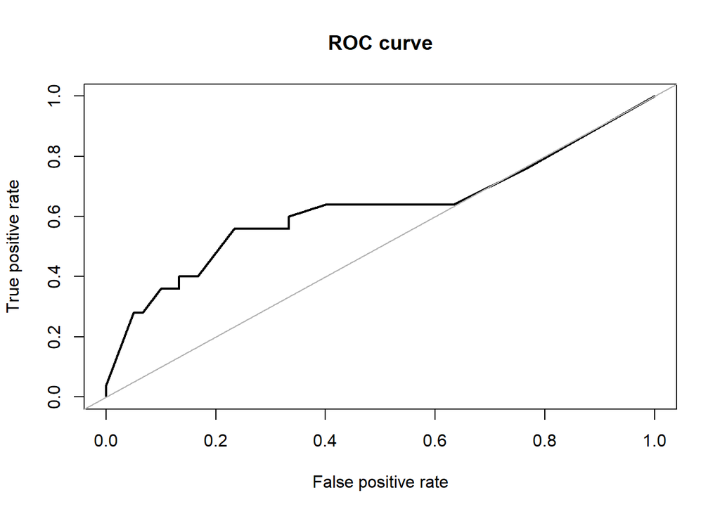

```
## Area under the curve (AUC): 0.626
```

```r
roc.curve(bdata_sample_df_use_test$class, predict(bdata.glm.dmy.caret, newdata = bdata_sample_df_use_test, type="prob")[,2])
```

This new model does quite good on the test data. It yields an overall accuracy of 65.88%, a sensitivity of 56% and a specificity of 70%, while producing only 11 false negatives. This is one of the smallest number of false negatives so far. Though the results are quite good, they are not as good as those obtained earlier using the default features in the logistic regression model.

Now, we can compare the model output of this logisitic regression result with that generated earlier to see if there is any significant difference between both.

```r
bdata.glm.caret$resample %>% data.frame %>% head
```

```
##   Accuracy       Kappa Resample
## 1     0.50  0.07407407   Fold01
## 2     0.45 -0.14583333   Fold02
## 3     0.85  0.68750000   Fold03
## 4     0.70  0.34782609   Fold04
## 5     0.65  0.12500000   Fold05
## 6     0.55 -0.02272727   Fold06
```

```r
bdata.glm.dmy.caret$resample %>% data.frame %>% head
```

```
##    Accuracy     Kappa Resample
## 1 0.7500000 0.4791667   Fold01
## 2 0.7500000 0.4318182   Fold02
## 3 0.6000000 0.1304348   Fold03
## 4 0.7619048 0.3859649   Fold04
## 5 0.5500000 0.1346154   Fold05
## 6 0.9000000 0.7826087   Fold06
```

First we check if both accuracy values are normally distributed

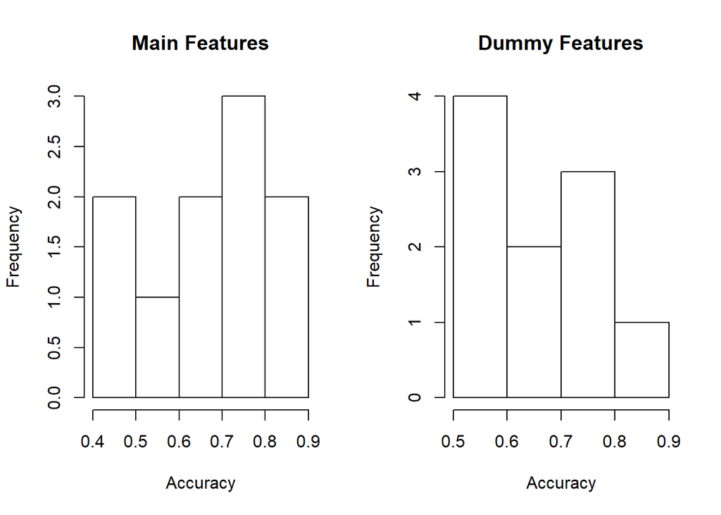

```r
par(mfrow=c(1,2))

hist(bdata.glm.caret$resample$Accuracy, breaks=5, main = "Main Features", xlab = "Accuracy")
hist(bdata.glm.dmy.caret$resample$Accuracy, breaks=5, main = "Dummy Features", xlab = "Accuracy")
```

The histograms appear normally distributed. However, we could still check using `shapiro.test`.

```r
bdata.glm.caret$resample$Accuracy %>% shapiro.test
```

```
##
##  Shapiro-Wilk normality test
##
## data:  .
## W = 0.8823, p-value = 0.1387
```

```r
bdata.glm.dmy.caret$resample$Accuracy %>% shapiro.test
```

```
##
##  Shapiro-Wilk normality test
##
## data:  .
## W = 0.95194, p-value = 0.6915
```

The null for this test is that the data is normally distributed. With `p-value` greater than $\alpha=0.05$, we can conclude that the two are normally distributed. Now, we do a t-test to check if there is any significant difference between both samples.

```r
t.test(bdata.glm.caret$resample$Accuracy, bdata.glm.dmy.caret$resample$Accuracy)
```

```
##
##  Welch Two Sample t-test
##
## data:  bdata.glm.caret$resample$Accuracy and bdata.glm.dmy.caret$resample$Accuracy
## t = 0.37125, df = 17.413, p-value = 0.7149
## alternative hypothesis: true difference in means is not equal to 0
## 95 percent confidence interval:
##  -0.1063378  0.1518516
## sample estimates:
## mean of x mean of y
## 0.6939474 0.6711905
```

It appears there is no significant difference between the cross-validation results of both models. Even though the one derived from the dummy variables produced fewer false negatives than the original logistic regression model, it does not appear significantly different from the original.

In our bid to improve the accuracy of this model, we consider other possible feture engineering tasks. Additional feature engineering tasks we could conduct include feature crossing between some of the features. The features `breast` and `breastQuad` refer to the same feature in some sense, only they are location dependent. We consider combining this two features into a group of dummy variables and then creating new models with this.

```r
#set seed
set.seed(80)


#Combine breast and breastQuad in a feature cross
dmy2 <- dummyVars(~ breast:breastQuad, data = bdata.shuffled)
dummy_df2 <- predict(dmy2, newdata = bdata.shuffled)

#Combine into new dataframe
bdata_sample_feature_cross <- data.frame(bdata.shuffled[,-c(8,9)], dummy_df2)

# #Convert to factors
bdata_sample_feature_cross[,-1] <- lapply(bdata_sample_feature_cross[,-1], factor)

#Check structure
str(bdata_sample_feature_cross)
```

```
## 'data.frame':    286 obs. of  18 variables:
##  $ class                          : Factor w/ 2 levels "no-recurrence-events",..: 1 2 1 1 2 1 2 2 1 2 ...
##  $ age                            : Factor w/ 6 levels "20-29","30-39",..: 2 5 4 2 3 5 4 5 4 4 ...
##  $ menopause                      : Factor w/ 3 levels "ge40","lt40",..: 3 1 1 3 3 1 1 1 1 3 ...
##  $ tumorSize                      : Factor w/ 11 levels "0-4","10-14",..: 8 6 6 5 6 4 6 6 8 7 ...
##  $ invNodes                       : Factor w/ 7 levels "0-2","12-14",..: 1 1 6 1 3 1 5 1 1 3 ...
##  $ nodeCaps                       : Factor w/ 2 levels "no","yes": 1 1 2 1 2 1 1 1 1 2 ...
##  $ degMalig                       : Factor w/ 3 levels "1","2","3": 2 3 2 2 3 1 3 3 3 3 ...
##  $ irradiat                       : Factor w/ 2 levels "no","yes": 2 2 1 1 1 1 1 1 1 1 ...
##  $ breastleft.breastQuadcentral   : Factor w/ 2 levels "0","1": 1 1 1 1 1 1 1 1 1 1 ...
##  $ breastright.breastQuadcentral  : Factor w/ 2 levels "0","1": 1 1 1 1 1 1 1 2 1 1 ...
##  $ breastleft.breastQuadleft_low  : Factor w/ 2 levels "0","1": 2 1 2 2 2 2 1 1 1 1 ...
##  $ breastright.breastQuadleft_low : Factor w/ 2 levels "0","1": 1 1 1 1 1 1 1 1 1 1 ...
##  $ breastleft.breastQuadleft_up   : Factor w/ 2 levels "0","1": 1 1 1 1 1 1 1 1 2 1 ...
##  $ breastright.breastQuadleft_up  : Factor w/ 2 levels "0","1": 1 2 1 1 1 1 2 1 1 1 ...
##  $ breastleft.breastQuadright_low : Factor w/ 2 levels "0","1": 1 1 1 1 1 1 1 1 1 1 ...
##  $ breastright.breastQuadright_low: Factor w/ 2 levels "0","1": 1 1 1 1 1 1 1 1 1 1 ...
##  $ breastleft.breastQuadright_up  : Factor w/ 2 levels "0","1": 1 1 1 1 1 1 1 1 1 1 ...
##  $ breastright.breastQuadright_up : Factor w/ 2 levels "0","1": 1 1 1 1 1 1 1 1 1 2 ...
```

```r
#Create training and test data

bdata_sample_feature_cross_train <- bdata_sample_feature_cross[ind.new,]
bdata_sample_feature_cross_test <- bdata_sample_feature_cross[-ind.new,]
```

When we attempt a logistic regression or naive-Bayes model with the output data frame, we do not get consistent results. It appears there is perfect separation for some of the data points, because of the many 0’s and 1’s present in the dummy variables created. However, a decision tree model works quite fine, even though dummy variables are not particularly suited as input for decision tree models. Decision tree models work best with categorical variables in their original form.

```r
###################################
# Create Decision Tree Model      #
# with crossed features           #
###################################

#set seed
set.seed(80)

#Build logistic regression model from identified features
bdata.ctree.dmy.caret <- train(class ~ .,
      data = bdata_sample_feature_cross_train,
      method = "ctree",
      trControl = trainControl(method = "cv", number = 10, sampling = "up"))

bdata.ctree.dmy.caret %>%
  predict(newdata = bdata_sample_feature_cross_test) %>% confusionMatrix(reference=bdata_sample_feature_cross_test$class, positive="recurrence-events")
```

```
## Confusion Matrix and Statistics
##
##                       Reference
## Prediction             no-recurrence-events recurrence-events
##   no-recurrence-events                   40                13
##   recurrence-events                      20                12
##
##                Accuracy : 0.6118
##                  95% CI : (0.4999, 0.7156)
##     No Information Rate : 0.7059
##     P-Value [Acc > NIR] : 0.9763
##
##                   Kappa : 0.1356
##
##  Mcnemar's Test P-Value : 0.2963
##
##             Sensitivity : 0.4800
##             Specificity : 0.6667
##          Pos Pred Value : 0.3750
##          Neg Pred Value : 0.7547
##              Prevalence : 0.2941
##          Detection Rate : 0.1412
##    Detection Prevalence : 0.3765
##       Balanced Accuracy : 0.5733
##
##        'Positive' Class : recurrence-events
##
```

The result is not particularly inspiring, though it is close to some of what we obtained earlier. Clearly dummifying these two variables doesn’t appear to provide additional insight.

## Results

Our initial assessment of the data set showed that it was highly imbalanced. We needed to treat this imbalance appropriately and used `ROSE` for this operation. We created a string of data sets combining both oversampling and undersampling. Going into the analyses, we observed that we would use oversampling more, since a part of the class, the `recurrence-events` class, was already small enough. In using oversampling and undersampling techniques in modeling building, we also leveraged the availability of a sampling option while training using the `caret` package.

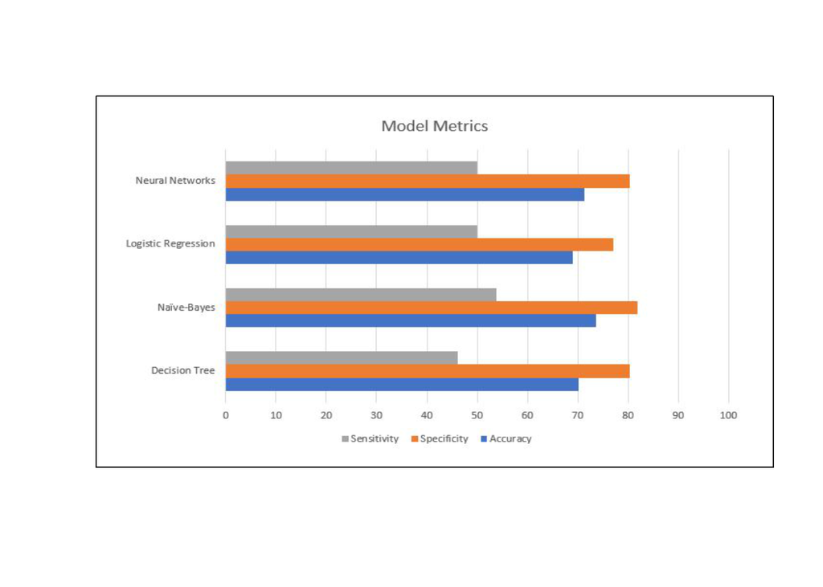

```r
require(jpeg)
img<-readJPEG("./images/modelmetrics.jpg")
plot(1:4, ty = 'n', ann = FALSE, xaxt = 'n', yaxt = 'n')
rasterImage(img,1,1,4,4)
```

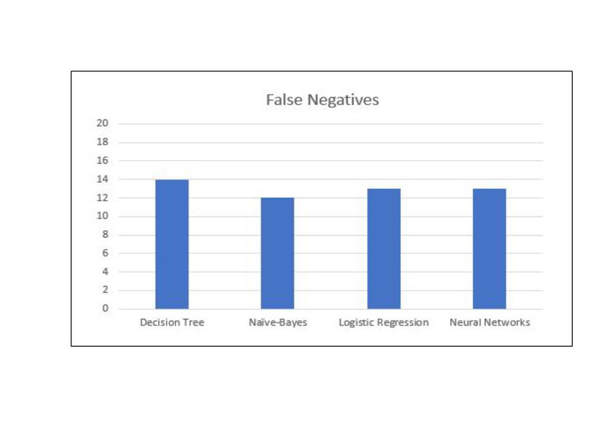

```r
require(jpeg)
img<-readJPEG("./images/fneg.jpg")
plot(1:4, ty = 'n', ann = FALSE, xaxt = 'n', yaxt = 'n')
rasterImage(img,1,1,4,4)
```

We proceeded to build four separate models so that we can compare their performances on the breast cancer data set. In qualifying a model, we look at the one which minimizes the false negatives. The decision tree model used first the doubly-sampled data set and then the synthetically generated data set. We used a seed value of 80 throughout this analysis. Our initial runs of the randomly sampled data sets helped throw light on what the models could produce. But the final training and testing were conducted using the `caret` package and leveraging its functionality to balanced the data set while simultaneously conducting cross-validation.

To obtain richer insight and more as an exploratory procedure, we combined every two possible features of the data set in order to check which delivered the best metrics using the naive-Bayes classifier. We were able to identify `age` and `tumorSize` as two features which delivered well on certain metrics as it relates to the data set. When these two were used to develop a naive-Bayes model, we were able to achieve an accuracy of 69% while maintaining a lower number of 10 false negatives.

Additional checks confirmed that the models were quite sensitive to the sampling techniques used. As a result, further examination was conducted to compare results from all these sampling methods including oversampling, undersampling, ROSE and SMOTE. We found that, for this data set, sampling up seemed to have a greater tendency to produce better accuracy values. Sampling down, on the other hand, was greater disposed to producing lower accuracy models.